# REPORT CONTROL CHECK V201

Thijs de Boer

2021

Last update: 2021-03-11 15:21:16

```r
load("C:/Users/Thijs/surfdrive/COVID vaccine/git/Control/NL - control check/.RData")
load("C:/Users/Thijs/surfdrive/COVID vaccine/git/Control/SE - control check/.RData")

df.def.error <- dplyr::bind_rows(df.def.NL, df.def.SE)

df.def.error <- df.def.error %>% mutate(duration.quartile = case_when(
  duration <= quantile(duration, probs = 0.25) ~ "Q1",
  duration > quantile(duration, probs = 0.25) & duration <= quantile(duration, probs = 0.5)  ~ "Q2",
  duration > quantile(duration, probs = 0.5) & duration <= quantile(duration, probs = 0.75)  ~ "Q3",
  duration > quantile(duration, probs = 0.75) ~ "Q4"))

df.def.error <- df.def.error %>% mutate(intro.submit.recoded = case_when(
  intro.submit < quantile(intro.submit, probs = 0.5) ~ "< median",
    intro.submit > quantile(intro.submit, probs = 0.5) ~ "> median"))

df.def.error$duration.quartile <- factor(df.def.error$duration.quartile, levels = c("Q1", "Q2", "Q3", "Q4"))

df.def.error$experimental.group <- factor(df.def.error$experimental.group, levels = c("no text", "advice", "independence"))

df.def.error.NL$experimental.group <- factor(df.def.error.NL$experimental.group, levels = c("no text", "advice"))
df.def.NL$experimental.group <- factor(df.def.NL$experimental.group, levels = c("no text", "advice"))
df.check.NL$experimental.group <- factor(df.check.NL$experimental.group, levels = c("no text", "advice"))
df.def.SE$experimental.group <- factor(df.def.SE$experimental.group, levels = c("no text", "advice", "independence"))
df.check.SE$experimental.group <- factor(df.check.SE$experimental.group, levels = c("no text", "advice", "independence"))

df.check <- dplyr::bind_rows(df.check.NL, df.check.SE)
df.total <- dplyr::bind_rows(df.total.NL, df.total.SE)
df.intro <- df.def.error %>% filter(intro.submit.recoded == "> median")
df.intro.NL <- df.intro %>% filter(country == "NL")
df.intro.SE <- df.intro %>% filter(country == "SE")

set_theme(
  base=theme_blank(),
  geom.outline.size = 0.01,
  geom.outline.color = "white",
  geom.label.size = 3,
  geom.label.color = "grey50")
```

# 1 Population

Total number of participants:

```r
df.total %>% nrow()
```

```
## [1] 888
```

Number of participants that failed the attention test:

```r
df.total %>% nrow() - df.total %>% filter(IMC=="1") %>% nrow()
```

```
## [1] 205
```

Participants between 0-17:

```r
df.total %>% filter(IMC=="1" & age < 18) %>% nrow()
```

```
## [1] 1
```

Percentage of participants who are at least 18 years old and did not fail the IMC:

```r
percent(df.def.error %>% nrow() / df.total  %>% nrow())
```

```
## [1] "77%"
```

Number of participants in this analysis:

```r
df.def.error %>% nrow()
```

```
## [1] 680
```

Number of participants in the final dataset that failed the manipulation check:

```r
df.def.error %>% nrow() - df.def.error %>% filter(manipulation.check=="1") %>% nrow()
```

```
## [1] 409
```

Which is:

```r
percent(df.def.error %>% filter(manipulation.check!="1") %>% nrow() / df.def.error %>% nrow(), accuracy = 0.01)
```

[output not shown]

# 2 Experiment: Perceived independence of EMA

## 2.1 Randomisation check

This table shows how many respondents are assigned to each experimental group.

```r
df.def.error %>%
  group_by(experimental.group) %>%
  tally()
```

```
## # A tibble: 3 x 2
##   experimental.group     n
## * <fct>              <int>
## 1 no text              286
## 2 advice               272
## 3 independence         122
```

## 2.2 Full dataset

### 2.2.1 Description

```r
df.def.error %>%
sjmisc::descr(perceived.independence.reversed, show = c("n", "NA.prc", "mean", "sd", "md", "iqr", "trimmed", "range", "skew")) %>%
  kbl(digits= 2) %>%
 kable_paper()
```

| var | n | NA.prc | mean | sd | md | trimmed | range | iqr | skew |
| --- | --- | --- | --- | --- | --- | --- | --- | --- | --- |
| perceived.independence.reversed | 680 | 0 | 3.23 | 1.34 | 3 | 3.2 | 6 (1-7) | 2 | 0.31 |

### 2.2.2 Histogram

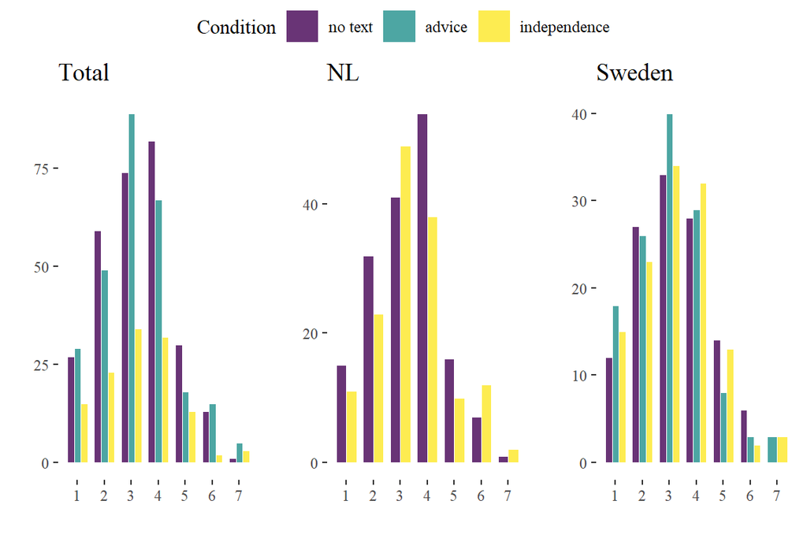

```r
ggarrange(df.def.error %>%
  ggplot(aes(x = perceived.independence.reversed, fill = experimental.group)) +
  geom_bar(width = 0.75,alpha = 0.8, position = position_dodge()) + labs(y = "", title = "Total") +
  scale_x_continuous(name="", breaks = 1:7) + scale_fill_manual(name = "Condition") +  scale_fill_viridis_d(name = "Condition") +
  theme_tufte(),

  df.def.error.NL  %>%
  ggplot(aes(x = perceived.independence.reversed, fill = experimental.group)) +
  geom_bar(width = 0.75,alpha = 0.8, position = position_dodge()) + labs(y = "", title = "NL") +
  scale_x_continuous(name="", breaks = 1:7) + scale_fill_manual(name = "Condition") +  scale_fill_viridis_d(name = "Condition") +
  theme_tufte(),

   df.def.SE %>%
  ggplot(aes(x = perceived.independence.reversed, fill = experimental.group)) +
  geom_bar(width = 0.75,alpha = 0.8, position = position_dodge()) + labs(y = "", title = "Sweden") +
  scale_x_continuous(name="", breaks = 1:7) + scale_fill_manual(name = "Condition") +  scale_fill_viridis_d(name = "Condition") +
  theme_tufte(),

  ncol = 3, common.legend = TRUE)
```

### 2.2.3 Statistics

**Regression**

```r
reg.perceived.independence.total <- lm(perceived.independence.reversed ~  experimental.group,
                    data = df.def.error,
                    na.action = na.omit)

reg.perceived.independence.SE <- lm(perceived.independence.reversed ~ experimental.group,
                    data = df.def.SE,
                    na.action = na.omit)

reg.perceived.independence.NL <- lm(perceived.independence.reversed ~  experimental.group,
                    data = df.def.error.NL,
                    na.action = na.omit)

tab_model(reg.perceived.independence.total, reg.perceived.independence.SE, reg.perceived.independence.NL, dv.labels = c("Perceived independence - Total", "Perceived independence - SE", "Perceived independence - NL"), title = "Perceived independence - no filter", show.ci = FALSE)
```

Perceived independence - no filter

|  | Perceived independence - Total |  | Perceived independence - SE |  | Perceived independence - NL |  |
| --- | --- | --- | --- | --- | --- | --- |
| Predictors | Estimates | p | Estimates | p | Estimates | p |
| (Intercept) | 3.25 | **<0.001** | 3.19 | **<0.001** | 3.30 | **<0.001** |
| experimental.group [advice] | -0.03 | 0.809 | -0.16 | 0.353 | 0.10 | 0.514 |
| experimental.group [independence] | -0.06 | 0.663 | -0.00 | 0.986 |  |  |
| Observations | 680 |  | 369 |  | 311 |  |
| R<sup>2</sup> / R<sup>2</sup> adjusted | 0.000 / -0.003 |  | 0.003 / -0.002 |  | 0.001 / -0.002 |  |

**Total**

```r
tadaa_aov(perceived.independence.reversed ~ experimental.group, data = df.def.error, print = "markdown")
```

Table 1: **One-Way ANOVA**: Using Type III Sum of Squares

| Term | df | SS | MS | F | p | $\eta^2$ | Cohen’s f |
| --- | --- | --- | --- | --- | --- | --- | --- |
| experimental.group | 2 | 0.35 | 0.18 | 0.1 | .906 | 0 | 0.02 |
| Residuals | 677 | 1217.86 | 1.8 |  |  |  |  |
| Total | 679 | 1218.21 | 1.98 |  |  |  |  |

**Sweden**

```r
tadaa_aov(perceived.independence.reversed ~ experimental.group, data = df.def.SE, print = "markdown")
```

Table 2: **One-Way ANOVA**: Using Type III Sum of Squares

| Term | df | SS | MS | F | p | $\eta^2$ | Cohen’s f |
| --- | --- | --- | --- | --- | --- | --- | --- |
| experimental.group | 2 | 2.1 | 1.05 | 0.57 | .565 | 0 | 0.06 |
| Residuals | 366 | 671.13 | 1.83 |  |  |  |  |
| Total | 368 | 673.22 | 2.88 |  |  |  |  |

**Netherlands**

```r
tadaa_t.test(data = df.def.error.NL, response = perceived.independence.reversed, group = experimental.group, print = "markdown")
```

Table 3: **Welch Two Sample t-test** with alternative hypothesis: $\mu_1 \neq \mu_2$

| Diff | $\mu_1$ no text | $\mu_2$ advice | t | SE | df | $CI_{95\%}$ | p | Cohen's d |
| --- | --- | --- | --- | --- | --- | --- | --- | --- |
| -0.1 | 3.3 | 3.39 | -0.65 | 0.15 | 299.16 | (-0.39 - 0.2) | .515 | -0.07 |

### 2.2.4 Histogram

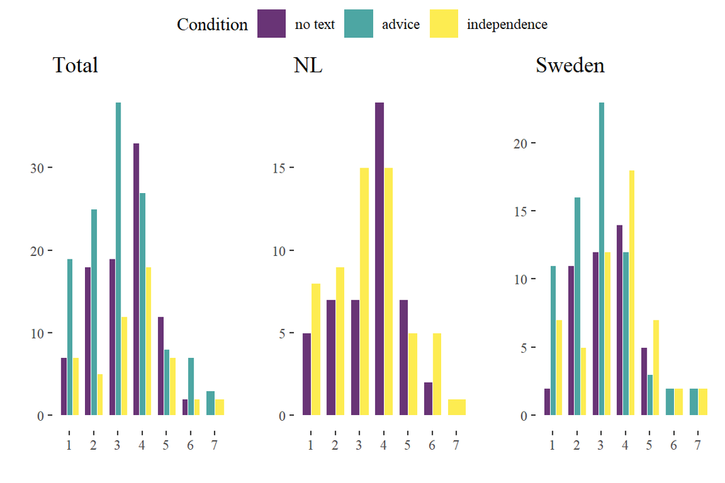

```r
ggarrange(df.check %>%
  ggplot(aes(x = perceived.independence.reversed, fill = experimental.group)) +
  geom_bar(width = 0.75,alpha = 0.8, position = position_dodge()) + labs(y = "", title = "Total") +
  scale_x_continuous(name="", breaks = 1:7) + scale_fill_manual(name = "Condition") +  scale_fill_viridis_d(name = "Condition") +
  theme_tufte(),

  df.check.NL %>%
  ggplot(aes(x = perceived.independence.reversed, fill = experimental.group)) +
  geom_bar(width = 0.75,alpha = 0.8, position = position_dodge()) + labs(y = "", title = "NL") +
  scale_x_continuous(name="", breaks = 1:7) + scale_fill_manual(name = "Condition") +  scale_fill_viridis_d(name = "Condition") +
  theme_tufte(),

    df.check.SE %>%
  ggplot(aes(x = perceived.independence.reversed, fill = experimental.group)) +
  geom_bar(width = 0.75,alpha = 0.8, position = position_dodge()) + labs(y = "", title = "Sweden") +
  scale_x_continuous(name="", breaks = 1:7) + scale_fill_manual(name = "Condition") +  scale_fill_viridis_d(name = "Condition") +
  theme_tufte(),

  ncol = 3, common.legend = TRUE)
```

### 2.2.5 Statistics

**Regression**

```r
reg.perceived.independence.total.check <- lm(perceived.independence.reversed ~  experimental.group,
                    data = df.check,
                    na.action = na.omit)

reg.perceived.independence.SE.check <- lm(perceived.independence.reversed ~ experimental.group,
                    data = df.check.SE,
                    na.action = na.omit)

reg.perceived.independence.NL.check <- lm(perceived.independence.reversed ~  experimental.group,
                    data = df.check.NL,
                    na.action = na.omit)

tab_model(reg.perceived.independence.total.check, reg.perceived.independence.SE.check, reg.perceived.independence.NL.check, dv.labels = c("Perceived independence - Total", "Perceived independence - SE", "Perceived independence - NL"), title = "Perceived independence - filter: manipulation check", show.ci = FALSE)
```

Perceived independence - filter: manipulation check

|  | Perceived independence - Total |  | Perceived independence - SE |  | Perceived independence - NL |  |
| --- | --- | --- | --- | --- | --- | --- |
| Predictors | Estimates | p | Estimates | p | Estimates | p |
| (Intercept) | 3.34 | **<0.001** | 3.20 | **<0.001** | 3.47 | **<0.001** |
| experimental.group [advice] | -0.24 | 0.214 | -0.29 | 0.267 | -0.14 | 0.619 |
| experimental.group [independence] | 0.17 | 0.484 | 0.30 | 0.272 |  |  |
| Observations | 271 |  | 166 |  | 105 |  |
| R<sup>2</sup> / R<sup>2</sup> adjusted | 0.013 / 0.006 |  | 0.034 / 0.023 |  | 0.002 / -0.007 |  |

**Total**

```r
tadaa_aov(perceived.independence.reversed ~ experimental.group, data = df.check, print = "markdown")
```

Table 4: **One-Way ANOVA**: Using Type III Sum of Squares

| Term | df | SS | MS | F | p | $\eta^2$ | Cohen’s f |
| --- | --- | --- | --- | --- | --- | --- | --- |
| experimental.group | 2 | 7.04 | 3.52 | 1.82 | .164 | 0.01 | 0.12 |
| Residuals | 268 | 519.35 | 1.94 |  |  |  |  |
| Total | 270 | 526.4 | 5.46 |  |  |  |  |

**Sweden**

```r
tadaa_aov(perceived.independence.reversed ~ experimental.group, data = df.check.SE, print = "markdown")
```

Table 5: **One-Way ANOVA**: Using Type III Sum of Squares

| Term | df | SS | MS | F | p | $\eta^2$ | Cohen’s f |
| --- | --- | --- | --- | --- | --- | --- | --- |
| experimental.group | 2 | 10.7 | 5.35 | 2.91 | .057 | 0.03 | 0.19 |
| Residuals | 163 | 299.88 | 1.84 |  |  |  |  |
| Total | 165 | 310.58 | 7.19 |  |  |  |  |

**Netherlands**

```r
tadaa_t.test(data = df.check.NL, response = perceived.independence.reversed, group = experimental.group, print = "markdown")
```

Table 6: **Welch Two Sample t-test** with alternative hypothesis: $\mu_1 \neq \mu_2$

| Diff | $\mu_1$ no text | $\mu_2$ advice | t | SE | df | $CI_{95\%}$ | p | Cohen's d |
| --- | --- | --- | --- | --- | --- | --- | --- | --- |
| 0.14 | 3.47 | 3.33 | 0.51 | 0.28 | 102.27 | (-0.41 - 0.69) | .615 | 0.1 |

## 2.3 Only those who spent more time on the introduction page of the case than the median participant

### 2.3.1 Description

```r
df.intro %>%
sjmisc::descr(perceived.independence.reversed, show = c("n", "NA.prc", "mean", "sd", "md", "iqr", "trimmed", "range", "skew")) %>%
  kbl(digits= 2) %>%
 kable_paper()
```

| var | n | NA.prc | mean | sd | md | trimmed | range | iqr | skew |
| --- | --- | --- | --- | --- | --- | --- | --- | --- | --- |
| perceived.independence.reversed | 340 | 0 | 3.25 | 1.37 | 3 | 3.21 | 6 (1-7) | 2 | 0.34 |

### 2.3.2 Histogram

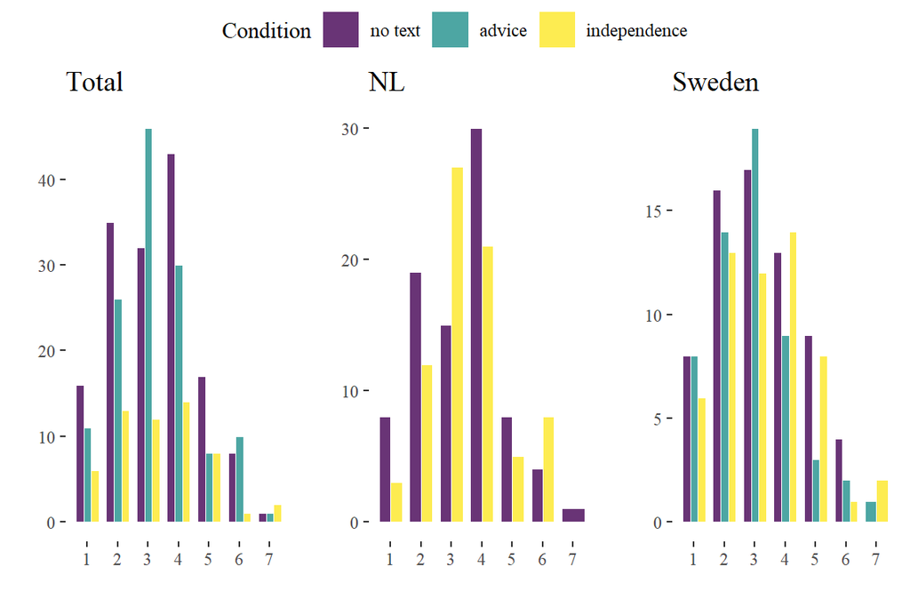

```r
ggarrange(df.intro %>%
  ggplot(aes(x = perceived.independence.reversed, fill = experimental.group)) +
  geom_bar(width = 0.75,alpha = 0.8, position = position_dodge()) + labs(y = "", title = "Total") +
  scale_x_continuous(name="", breaks = 1:7) + scale_fill_manual(name = "Condition") +  scale_fill_viridis_d(name = "Condition") +
  theme_tufte(),

  df.intro.NL   %>%
  ggplot(aes(x = perceived.independence.reversed, fill = experimental.group)) +
  geom_bar(width = 0.75,alpha = 0.8, position = position_dodge()) + labs(y = "", title = "NL") +
  scale_x_continuous(name="", breaks = 1:7) + scale_fill_manual(name = "Condition") +  scale_fill_viridis_d(name = "Condition") +
  theme_tufte(),

 df.intro.SE  %>%
  ggplot(aes(x = perceived.independence.reversed, fill = experimental.group)) +
  geom_bar(width = 0.75,alpha = 0.8, position = position_dodge()) + labs(y = "", title = "Sweden") +
  scale_x_continuous(name="", breaks = 1:7) + scale_fill_manual(name = "Condition") +  scale_fill_viridis_d(name = "Condition") +
  theme_tufte(),

  ncol = 3, common.legend = TRUE)
```

### 2.3.3 Statistics

**Regression**

```r
reg.perceived.independence.total.intro <- lm(perceived.independence.reversed ~  experimental.group,
                    data = df.intro,
                    na.action = na.omit)

reg.perceived.independence.SE.intro <- lm(perceived.independence.reversed ~ experimental.group,
                    data =  df.intro.SE,
                    na.action = na.omit)

reg.perceived.independence.NL.intro <- lm(perceived.independence.reversed ~  experimental.group,
                    data =   df.intro.NL,
                    na.action = na.omit)

tab_model(reg.perceived.independence.total.intro, reg.perceived.independence.SE.intro, reg.perceived.independence.NL.intro, dv.labels = c("Perceived independence - Total", "Perceived independence - SE", "Perceived independence - NL"), title = "Perceived independence - filter: introduction of case", show.ci = FALSE)
```

Perceived independence - filter: introduction of case

|  | Perceived independence - Total |  | Perceived independence - SE |  | Perceived independence - NL |  |
| --- | --- | --- | --- | --- | --- | --- |
| Predictors | Estimates | p | Estimates | p | Estimates | p |
| (Intercept) | 3.25 | **<0.001** | 3.16 | **<0.001** | 3.32 | **<0.001** |
| experimental.group [advice] | -0.01 | 0.963 | -0.25 | 0.323 | 0.17 | 0.417 |
| experimental.group [independence] | 0.04 | 0.868 | 0.12 | 0.635 |  |  |
| Observations | 340 |  | 179 |  | 161 |  |
| R<sup>2</sup> / R<sup>2</sup> adjusted | 0.000 / -0.006 |  | 0.012 / 0.000 |  | 0.004 / -0.002 |  |

**Total**

```r
tadaa_aov(perceived.independence.reversed ~ experimental.group, data = df.intro, print = "markdown")
```

Table 7: **One-Way ANOVA**: Using Type III Sum of Squares

| Term | df | SS | MS | F | p | $\eta^2$ | Cohen’s f |
| --- | --- | --- | --- | --- | --- | --- | --- |
| experimental.group | 2 | 0.08 | 0.04 | 0.02 | .98 | 0 | 0.01 |
| Residuals | 337 | 638.17 | 1.89 |  |  |  |  |
| Total | 339 | 638.25 | 1.93 |  |  |  |  |

**Sweden**

```r
tadaa_aov(perceived.independence.reversed ~ experimental.group, data = df.intro.SE, print = "markdown")
```

Table 8: **One-Way ANOVA**: Using Type III Sum of Squares

| Term | df | SS | MS | F | p | $\eta^2$ | Cohen’s f |
| --- | --- | --- | --- | --- | --- | --- | --- |
| experimental.group | 2 | 4.12 | 2.06 | 1.03 | .358 | 0.01 | 0.11 |
| Residuals | 176 | 351.18 | 2 |  |  |  |  |
| Total | 178 | 355.3 | 4.06 |  |  |  |  |

```r
tadaa_t.test(data = df.intro, response = perceived.independence.reversed, group = experimental.group, print = "markdown")
```

Table 9: **Welch Two Sample t-test** with alternative hypothesis: $\mu_1 \neq \mu_2$

| Diff | $\mu_1$ no text | $\mu_2$ advice | t | SE | df | $CI_{95\%}$ | p | Cohen's d |
| --- | --- | --- | --- | --- | --- | --- | --- | --- |
| 0.01 | 3.25 | 3.24 | 0.05 | 0.16 | 279.21 | (-0.31 - 0.32) | .962 | 0.01 |

# 3 Credbility

## 3.1 Full dataset

### 3.1.1 Description

```r
df.def.error %>%
sjmisc::descr(credibility.index, show = c("n", "NA.prc", "mean", "sd", "md", "iqr", "trimmed", "range", "skew")) %>%
  kbl(digits= 2) %>%
 kable_paper()
```

| var | n | NA.prc | mean | sd | md | trimmed | range | iqr | skew |
| --- | --- | --- | --- | --- | --- | --- | --- | --- | --- |
| credibility.index | 680 | 0 | 4.67 | 1.14 | 4.67 | 4.68 | 5.5 (1.5-7) | 1.5 | -0.13 |

### 3.1.2 Histogram

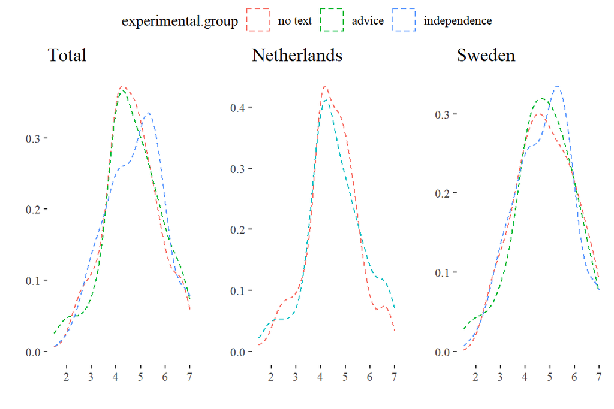

```r
ggarrange(df.def.error %>% ggplot(aes(x= credibility.index, color = experimental.group)) +
 geom_density(alpha= .1, linetype= "dashed") + theme(axis.title.y = element_blank()) + labs(y = "", title = "Total") +
  scale_x_continuous(name="", breaks = 1:7) + scale_fill_manual(name = "Condition") +  scale_fill_viridis_d(name = "Condition") +
  theme_tufte(),

 df.def.error.NL
 %>% ggplot(aes(x= credibility.index, color = experimental.group)) +
 geom_density(alpha= .1, linetype= "dashed") + theme(axis.title.y = element_blank()) + labs(y = "", title = "Netherlands") +
  scale_x_continuous(name="", breaks = 1:7) + scale_fill_manual(name = "Condition") +  scale_fill_viridis_d(name = "Condition") +
  theme_tufte(),

  df.def.SE  %>% ggplot(aes(x= credibility.index, color = experimental.group)) +
 geom_density(alpha= .1, linetype= "dashed") + theme(axis.title.y = element_blank()) + labs(y = "", title = "Sweden") +
  scale_x_continuous(name="", breaks = 1:7) + scale_fill_manual(name = "Condition") +  scale_fill_viridis_d(name = "Condition") +
  theme_tufte(),

  ncol = 3, common.legend = TRUE)
```

### 3.1.3 Statistics

**Regression**

```r
reg.credibility.total <- lm(credibility.index ~  experimental.group,
                    data = df.def.error,
                    na.action = na.omit)

reg.credibility.SE <- lm(credibility.index ~ experimental.group,
                    data =  df.def.SE,
                    na.action = na.omit)

reg.credibility.NL <- lm(credibility.index ~  experimental.group,
                    data =   df.def.error.NL,
                    na.action = na.omit)

tab_model(reg.credibility.total, reg.credibility.SE, reg.credibility.NL, dv.labels = c("Credibility - Total", "Credibility - SE", "Credibility - NL"), title = "Credibility - no filter", show.ci = FALSE)
```

Credibility - no filter

|  | Credibility - Total |  | Credibility - SE |  | Credibility - NL |  |
| --- | --- | --- | --- | --- | --- | --- |
| Predictors | Estimates | p | Estimates | p | Estimates | p |
| (Intercept) | 4.61 | **<0.001** | 4.81 | **<0.001** | 4.48 | **<0.001** |
| experimental.group [advice] | 0.07 | 0.491 | -0.04 | 0.794 | 0.13 | 0.292 |
| experimental.group [independence] | 0.15 | 0.211 | -0.04 | 0.803 |  |  |
| Observations | 680 |  | 369 |  | 311 |  |
| R<sup>2</sup> / R<sup>2</sup> adjusted | 0.002 / -0.001 |  | 0.000 / -0.005 |  | 0.004 / 0.000 |  |

**Total**

```r
tadaa_aov(credibility.index ~ experimental.group, data = df.def.error, print = "markdown")
```

Table 10: **One-Way ANOVA**: Using Type III Sum of Squares

| Term | df | SS | MS | F | p | $\eta^2$ | Cohen’s f |
| --- | --- | --- | --- | --- | --- | --- | --- |
| experimental.group | 2 | 2.1 | 1.05 | 0.81 | .445 | 0 | 0.05 |
| Residuals | 677 | 879.61 | 1.3 |  |  |  |  |
| Total | 679 | 881.72 | 2.35 |  |  |  |  |

**Sweden**

```r
tadaa_aov(credibility.index ~ experimental.group, data = df.def.SE, print = "markdown")
```

Table 11: **One-Way ANOVA**: Using Type III Sum of Squares

| Term | df | SS | MS | F | p | $\eta^2$ | Cohen’s f |
| --- | --- | --- | --- | --- | --- | --- | --- |
| experimental.group | 2 | 0.12 | 0.06 | 0.04 | .958 | 0 | 0.02 |
| Residuals | 366 | 507.64 | 1.39 |  |  |  |  |
| Total | 368 | 507.76 | 1.45 |  |  |  |  |

**Netherlands**

```r
tadaa_t.test(data = df.def.error.NL, response = credibility.index, group = experimental.group, print = "markdown")
```

Table 12: **Welch Two Sample t-test** with alternative hypothesis: $\mu_1 \neq \mu_2$

| Diff | $\mu_1$ no text | $\mu_2$ advice | t | SE | df | $CI_{95\%}$ | p | Cohen's d |
| --- | --- | --- | --- | --- | --- | --- | --- | --- |
| -0.13 | 4.48 | 4.61 | -1.05 | 0.12 | 291.27 | (-0.37 - 0.11) | .296 | -0.12 |

## 3.2 Filtering out those who failed the manipulation check

Participants that received the erroneous manipulation check are filtered out as well.

### 3.2.1 Description

```r
df.check %>%
sjmisc::descr(credibility.index, show = c("n", "NA.prc", "mean", "sd", "md", "iqr", "trimmed", "range", "skew")) %>%
  kbl(digits= 2) %>%
 kable_paper()
```

| var | n | NA.prc | mean | sd | md | trimmed | range | iqr | skew |
| --- | --- | --- | --- | --- | --- | --- | --- | --- | --- |
| credibility.index | 271 | 0 | 4.7 | 1.2 | 4.67 | 4.74 | 5.5 (1.5-7) | 1.5 | -0.27 |

### 3.2.2 Histogram

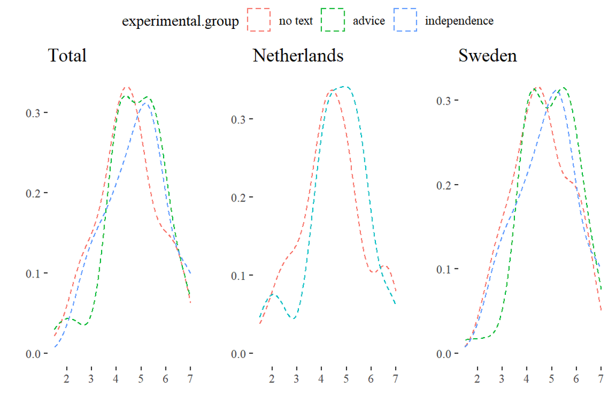

```r
ggarrange(df.check%>% ggplot(aes(x= credibility.index, color = experimental.group)) +
 geom_density(alpha= .1, linetype= "dashed") + theme(axis.title.y = element_blank()) + labs(y = "", title = "Total") +
  scale_x_continuous(name="", breaks = 1:7) + scale_fill_manual(name = "Condition") +  scale_fill_viridis_d(name = "Condition") +
  theme_tufte(),

 df.check.NL %>% ggplot(aes(x= credibility.index, color = experimental.group)) +
 geom_density(alpha= .1, linetype= "dashed") + theme(axis.title.y = element_blank()) + labs(y = "", title = "Netherlands") +
  scale_x_continuous(name="", breaks = 1:7) + scale_fill_manual(name = "Condition") +  scale_fill_viridis_d(name = "Condition") +
  theme_tufte(),

  df.check.SE %>% ggplot(aes(x= credibility.index, color = experimental.group)) +
 geom_density(alpha= .1, linetype= "dashed") + theme(axis.title.y = element_blank()) + labs(y = "", title = "Sweden") +
  scale_x_continuous(name="", breaks = 1:7) + scale_fill_manual(name = "Condition") +  scale_fill_viridis_d(name = "Condition") +
  theme_tufte(),

  ncol = 3, common.legend = TRUE)
```

### 3.2.3 Statistics

**Regression**

```r
reg.credibility.total.check <- lm(credibility.index ~  experimental.group,
                    data = df.check,
                    na.action = na.omit)

reg.credibility.SE.check  <- lm(credibility.index ~ experimental.group,
                    data =  df.check.SE,
                    na.action = na.omit)

reg.credibility.NL.check <- lm(credibility.index ~  experimental.group,
                    data =   df.check.NL,
                    na.action = na.omit)

tab_model(reg.credibility.total.check, reg.credibility.SE.check, reg.credibility.NL.check, dv.labels = c("Credibility - Total", "Credibility - SE", "Credibility - NL"), title = "Credibility - filter: manipulation check", show.ci = FALSE)
```

Credibility - filter: manipulation check

|  | Credibility - Total |  | Credibility - SE |  | Credibility - NL |  |
| --- | --- | --- | --- | --- | --- | --- |
| Predictors | Estimates | p | Estimates | p | Estimates | p |
| (Intercept) | 4.48 | **<0.001** | 4.56 | **<0.001** | 4.40 | **<0.001** |
| experimental.group [advice] | 0.33 | **0.045** | 0.38 | 0.092 | 0.26 | 0.305 |
| experimental.group [independence] | 0.35 | 0.090 | 0.27 | 0.260 |  |  |
| Observations | 271 |  | 166 |  | 105 |  |
| R<sup>2</sup> / R<sup>2</sup> adjusted | 0.018 / 0.010 |  | 0.018 / 0.005 |  | 0.010 / 0.001 |  |

**Total**

```r
tadaa_aov(credibility.index ~ experimental.group, data = df.check, print = "markdown")
```

Table 13: **One-Way ANOVA**: Using Type III Sum of Squares

| Term | df | SS | MS | F | p | $\eta^2$ | Cohen’s f |
| --- | --- | --- | --- | --- | --- | --- | --- |
| experimental.group | 2 | 6.91 | 3.45 | 2.41 | .092 | 0.02 | 0.13 |
| Residuals | 268 | 384.36 | 1.43 |  |  |  |  |
| Total | 270 | 391.27 | 4.89 |  |  |  |  |

**Sweden**

```r
tadaa_aov(credibility.index ~ experimental.group, data = df.check.SE, print = "markdown")
```

Table 14: **One-Way ANOVA**: Using Type III Sum of Squares

| Term | df | SS | MS | F | p | $\eta^2$ | Cohen’s f |
| --- | --- | --- | --- | --- | --- | --- | --- |
| experimental.group | 2 | 3.88 | 1.94 | 1.46 | .236 | 0.02 | 0.13 |
| Residuals | 163 | 217.09 | 1.33 |  |  |  |  |
| Total | 165 | 220.96 | 3.27 |  |  |  |  |

**Netherlands**

```r
tadaa_t.test(data = df.check.NL, response = credibility.index, group = experimental.group, print = "markdown")
```

Table 15: **Welch Two Sample t-test** with alternative hypothesis: $\mu_1 \neq \mu_2$

| Diff | $\mu_1$ no text | $\mu_2$ advice | t | SE | df | $CI_{95\%}$ | p | Cohen's d |
| --- | --- | --- | --- | --- | --- | --- | --- | --- |
| -0.26 | 4.4 | 4.65 | -1.02 | 0.25 | 96.31 | (-0.75 - 0.24) | .308 | -0.2 |

## 3.3 Only those who spent more time on the introduction page of the case than the median participant

### 3.3.1 Description

```r
df.intro %>%
sjmisc::descr(credibility.index, show = c("n", "NA.prc", "mean", "sd", "md", "iqr", "trimmed", "range", "skew")) %>%
  kbl(digits= 2) %>%
 kable_paper()
```

| var | n | NA.prc | mean | sd | md | trimmed | range | iqr | skew |
| --- | --- | --- | --- | --- | --- | --- | --- | --- | --- |
| credibility.index | 340 | 0 | 4.86 | 1.18 | 4.92 | 4.89 | 5.5 (1.5-7) | 1.67 | -0.26 |

### 3.3.2 Histogram

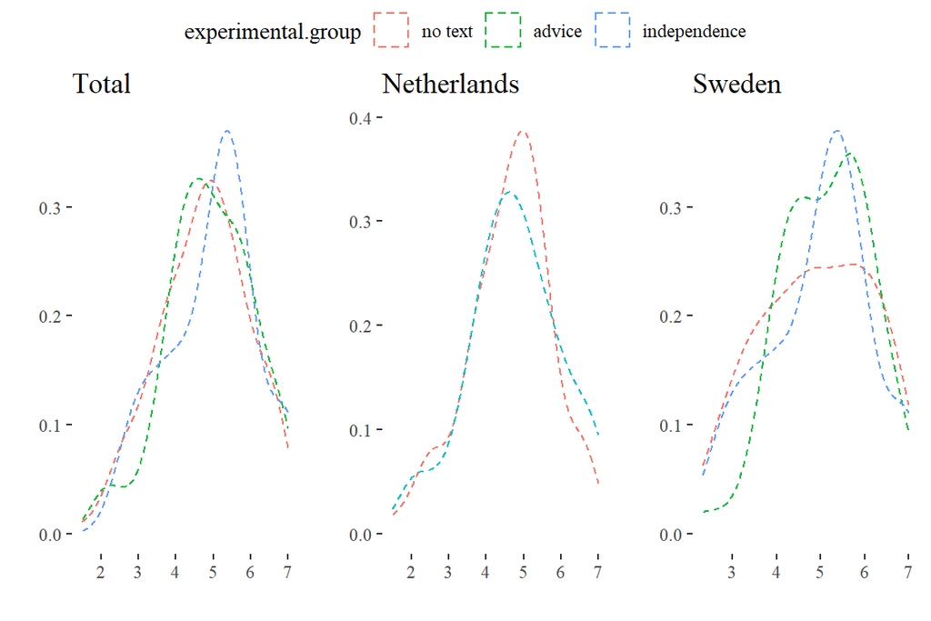

```r
ggarrange(df.intro %>% ggplot(aes(x= credibility.index, color = experimental.group)) +
 geom_density(alpha= .1, linetype= "dashed") + theme(axis.title.y = element_blank()) + labs(y = "", title = "Total") +
  scale_x_continuous(name="", breaks = 1:7) + scale_fill_manual(name = "Condition") +  scale_fill_viridis_d(name = "Condition") +
  theme_tufte(),

  df.intro.NL %>% ggplot(aes(x= credibility.index, color = experimental.group)) +
 geom_density(alpha= .1, linetype= "dashed") + theme(axis.title.y = element_blank()) + labs(y = "", title = "Netherlands") +
  scale_x_continuous(name="", breaks = 1:7) + scale_fill_manual(name = "Condition") +  scale_fill_viridis_d(name = "Condition") +
  theme_tufte(),

  df.intro.SE %>%  ggplot(aes(x= credibility.index, color = experimental.group)) +
 geom_density(alpha= .1, linetype= "dashed") + theme(axis.title.y = element_blank()) + labs(y = "", title = "Sweden") +
  scale_x_continuous(name="", breaks = 1:7) + scale_fill_manual(name = "Condition") +  scale_fill_viridis_d(name = "Condition") +
  theme_tufte(),

  ncol = 3, common.legend = TRUE)
```

### 3.3.3 Statistics

**Regression**

```r
reg.credibility.total.intro <- lm(credibility.index ~  experimental.group,
                    data = df.intro,
                    na.action = na.omit)

reg.credibility.SE.intro <- lm(credibility.index ~ experimental.group,
                    data =  df.intro.SE,
                    na.action = na.omit)

reg.credibility.NL.intro <- lm(credibility.index ~  experimental.group,
                    data =   df.intro.NL,
                    na.action = na.omit)

tab_model(reg.credibility.total.intro, reg.credibility.SE.intro, reg.credibility.NL.intro, dv.labels = c("Credibility - Total", "Perceived independence - SE", "Credibility - NL"), title = "Credibility - filter: introduction of case", show.ci = FALSE)
```

Credibility - filter: introduction of case

|  | Credibility - Total |  | Perceived independence - SE |  | Credibility - NL |  |
| --- | --- | --- | --- | --- | --- | --- |
| Predictors | Estimates | p | Estimates | p | Estimates | p |
| (Intercept) | 4.75 | **<0.001** | 4.90 | **<0.001** | 4.64 | **<0.001** |
| experimental.group [advice] | 0.17 | 0.216 | 0.25 | 0.243 | 0.13 | 0.497 |
| experimental.group [independence] | 0.23 | 0.206 | 0.08 | 0.690 |  |  |
| Observations | 340 |  | 179 |  | 161 |  |
| R<sup>2</sup> / R<sup>2</sup> adjusted | 0.007 / 0.001 |  | 0.008 / -0.003 |  | 0.003 / -0.003 |  |

**Total**

```r
tadaa_aov(credibility.index ~ experimental.group, data = df.intro, print = "markdown")
```

Table 16: **One-Way ANOVA**: Using Type III Sum of Squares

| Term | df | SS | MS | F | p | $\eta^2$ | Cohen’s f |
| --- | --- | --- | --- | --- | --- | --- | --- |
| experimental.group | 2 | 3.21 | 1.6 | 1.16 | .315 | 0.01 | 0.08 |
| Residuals | 337 | 465.87 | 1.38 |  |  |  |  |
| Total | 339 | 469.07 | 2.99 |  |  |  |  |

**Sweden**

```r
tadaa_aov(credibility.index~ experimental.group, data = df.intro.SE, print = "markdown")
```

Table 17: **One-Way ANOVA**: Using Type III Sum of Squares

| Term | df | SS | MS | F | p | $\eta^2$ | Cohen’s f |
| --- | --- | --- | --- | --- | --- | --- | --- |
| experimental.group | 2 | 1.91 | 0.96 | 0.7 | .499 | 0.01 | 0.09 |
| Residuals | 176 | 241.33 | 1.37 |  |  |  |  |
| Total | 178 | 243.25 | 2.33 |  |  |  |  |

**Netherlands**

```r
tadaa_t.test(data = df.intro.NL, response = credibility.index, group = experimental.group, print = "markdown")
```

Table 18: **Welch Two Sample t-test** with alternative hypothesis: $\mu_1 \neq \mu_2$

| Diff | $\mu_1$ no text | $\mu_2$ advice | t | SE | df | $CI_{95\%}$ | p | Cohen's d |
| --- | --- | --- | --- | --- | --- | --- | --- | --- |
| -0.13 | 4.64 | 4.76 | -0.68 | 0.19 | 152.48 | (-0.49 - 0.24) | .499 | -0.11 |

# 4 Credibility dimensions

## 4.1 Internal consistency

### 4.1.1 Non-interference

```r
df.def.error %>% select(credibility.item1:credibility.item3.reversed) %>% psych::alpha() -> alpha.noninterference

alpha.noninterference$total %>%
  kbl(digits= 2, caption = "Cronbach's alpha: non-interference") %>%
 kable_paper()
```

Cronbach’s alpha: non-interference

|  | raw_alpha | std.alpha | G6(smc) | average_r | S/N | ase | mean | sd | median_r |
| --- | --- | --- | --- | --- | --- | --- | --- | --- | --- |
|  | 0.78 | 0.78 | 0.73 | 0.54 | 3.58 | 0.01 | 4.18 | 1.37 | 0.48 |

### 4.1.2 Expertise

```r
 df.def.error %>% select(credibility.item4,credibility.item5) %>% psych::alpha() -> alpha.expertise

alpha.expertise$total %>%
  kbl(digits= 2, caption = "Cronbach's alpha: expertise") %>%
 kable_paper()
```

Cronbach’s alpha: expertise

|  | raw_alpha | std.alpha | G6(smc) | average_r | S/N | ase | mean | sd | median_r |
| --- | --- | --- | --- | --- | --- | --- | --- | --- | --- |
|  | 0.86 | 0.86 | 0.75 | 0.75 | 5.98 | 0.01 | 5.08 | 1.35 | 0.75 |

## 4.2 Description

```r
df.def.error %>% select(credibility.expert, credibility.noninterference, credibility.stability)  %>%
sjmisc::descr(show = c("n", "NA.prc", "mean", "sd", "md", "iqr", "trimmed", "range", "skew")) %>%
  kbl(digits= 2) %>%
 kable_paper()
```

| var | n | NA.prc | mean | sd | md | trimmed | range | iqr | skew |
| --- | --- | --- | --- | --- | --- | --- | --- | --- | --- |
| credibility.expert | 680 | 0 | 5.08 | 1.35 | 5 | 5.17 | 6 (1-7) | 2.00 | -0.64 |
| credibility.noninterference | 680 | 0 | 4.18 | 1.37 | 4 | 4.20 | 6 (1-7) | 1.67 | -0.11 |
| credibility.stability | 680 | 0 | 5.32 | 1.27 | 5 | 5.38 | 6 (1-7) | 2.00 | -0.49 |

## 4.3 Histogram

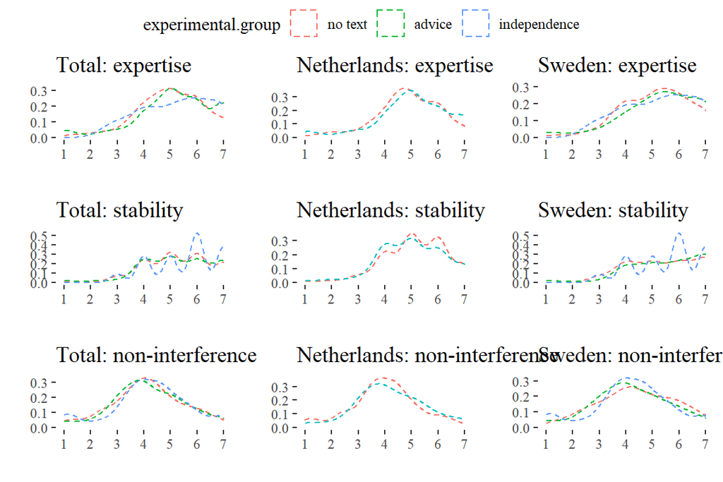

```r
ggarrange(df.def.error %>% ggplot(aes(x= credibility.expert, color = experimental.group)) +
 geom_density(alpha= .1, linetype= "dashed") + theme(axis.title = element_blank()) + labs(y = "", title = "Total: expertise") +  scale_x_continuous(name="", breaks = 1:7) + scale_fill_manual(name = "Condition") +  scale_fill_viridis_d(name = "Condition") +
  theme_tufte(),

 df.def.error.NL %>% ggplot(aes(x= credibility.expert, color = experimental.group)) +
 geom_density(alpha= .1, linetype= "dashed") + theme(axis.title = element_blank()) + labs(y = "", title = "Netherlands: expertise") +  scale_x_continuous(name="", breaks = 1:7) + scale_fill_manual(name = "Condition") +  scale_fill_viridis_d(name = "Condition") +
  theme_tufte(),

  df.def.SE %>% ggplot(aes(x= credibility.expert, color = experimental.group)) +
 geom_density(alpha= .1, linetype= "dashed") + theme(axis.title = element_blank()) + labs(y = "", title = "Sweden: expertise") +  scale_x_continuous(name="", breaks = 1:7) + scale_fill_manual(name = "Condition") +  scale_fill_viridis_d(name = "Condition") +
  theme_tufte(),

 df.def.error %>% ggplot(aes(x= credibility.stability, color = experimental.group)) +
 geom_density(alpha= .1, linetype= "dashed") + theme(axis.title = element_blank()) + labs(y = "", title = "Total: stability") +  scale_x_continuous(name="", breaks = 1:7) + scale_fill_manual(name = "Condition") +  scale_fill_viridis_d(name = "Condition") +
  theme_tufte(),

 df.def.error.NL %>% ggplot(aes(x= credibility.stability, color = experimental.group)) +
 geom_density(alpha= .1, linetype= "dashed") + theme(axis.title = element_blank()) + labs(y = "", title = "Netherlands: stability") +  scale_x_continuous(name="", breaks = 1:7) + scale_fill_manual(name = "Condition") +  scale_fill_viridis_d(name = "Condition") +
  theme_tufte(),

  df.def.SE %>% ggplot(aes(x= credibility.stability, color = experimental.group)) +
 geom_density(alpha= .1, linetype= "dashed") + theme(axis.title = element_blank()) + labs(y = "", title = "Sweden: stability") +  scale_x_continuous(name="", breaks = 1:7) + scale_fill_manual(name = "Condition") +  scale_fill_viridis_d(name = "Condition") +
  theme_tufte(),

 df.def.error %>% ggplot(aes(x= credibility.noninterference, color = experimental.group)) +
 geom_density(alpha= .1, linetype= "dashed") + theme(axis.title = element_blank()) + labs(y = "", title = "Total: non-interference") +  scale_x_continuous(name="", breaks = 1:7) + scale_fill_manual(name = "Condition") +  scale_fill_viridis_d(name = "Condition") +
  theme_tufte(),

 df.def.error.NL %>% ggplot(aes(x= credibility.noninterference, color = experimental.group)) +
 geom_density(alpha= .1, linetype= "dashed") + theme(axis.title = element_blank()) + labs(y = "", title = "Netherlands: non-interference") +  scale_x_continuous(name="", breaks = 1:7) + scale_fill_manual(name = "Condition") +  scale_fill_viridis_d(name = "Condition") +
  theme_tufte(),

  df.def.SE %>% ggplot(aes(x= credibility.noninterference, color = experimental.group)) +
 geom_density(alpha= .1, linetype= "dashed") + theme(axis.title = element_blank()) + labs(y = "", title = "Sweden: non-interference") +  scale_x_continuous(name="", breaks = 1:7) + scale_fill_manual(name = "Condition") +  scale_fill_viridis_d(name = "Condition") +
  theme_tufte(),
  ncol = 3, nrow = 3, common.legend = TRUE)
```

## 4.4 Statistics: full dataset

### 4.4.1 Expertise

**Regression**

```r
reg.credibility.expertise.total <- lm(credibility.expert ~  experimental.group,
                    data = df.def.error,
                    na.action = na.omit)

reg.credibility.expertise.SE <- lm(credibility.expert ~ experimental.group,
                    data =  df.def.SE,
                    na.action = na.omit)

reg.credibility.NL <- lm(credibility.expert ~  experimental.group,
                    data =   df.def.error.NL,
                    na.action = na.omit)

tab_model(reg.credibility.expertise.total, reg.credibility.expertise.SE, reg.credibility.NL, dv.labels = c("Expertise - Total", "Expertise - SE", "Expertise - NL"), title = "Expertise - no filter", show.ci = FALSE)
```

Expertise - no filter

|  | Expertise - Total |  | Expertise - SE |  | Expertise - NL |  |
| --- | --- | --- | --- | --- | --- | --- |
| Predictors | Estimates | p | Estimates | p | Estimates | p |
| (Intercept) | 4.98 | **<0.001** | 5.14 | **<0.001** | 4.87 | **<0.001** |
| experimental.group [advice] | 0.13 | 0.270 | 0.11 | 0.526 | 0.12 | 0.439 |
| experimental.group [independence] | 0.23 | 0.108 | 0.08 | 0.651 |  |  |
| Observations | 680 |  | 369 |  | 311 |  |
| R<sup>2</sup> / R<sup>2</sup> adjusted | 0.004 / 0.001 |  | 0.001 / -0.004 |  | 0.002 / -0.001 |  |

**Total**

```r
tadaa_aov(credibility.expert ~ experimental.group, data = df.def.error, print = "markdown")
```

Table 19: **One-Way ANOVA**: Using Type III Sum of Squares

| Term | df | SS | MS | F | p | $\eta^2$ | Cohen’s f |
| --- | --- | --- | --- | --- | --- | --- | --- |
| experimental.group | 2 | 5.22 | 2.61 | 1.44 | .239 | 0 | 0.07 |
| Residuals | 677 | 1230.46 | 1.82 |  |  |  |  |
| Total | 679 | 1235.67 | 4.43 |  |  |  |  |

**Sweden**

```r
tadaa_aov(credibility.expert ~ experimental.group, data = df.def.SE, print = "markdown")
```

Table 20: **One-Way ANOVA**: Using Type III Sum of Squares

| Term | df | SS | MS | F | p | $\eta^2$ | Cohen’s f |
| --- | --- | --- | --- | --- | --- | --- | --- |
| experimental.group | 2 | 0.8 | 0.4 | 0.21 | .809 | 0 | 0.03 |
| Residuals | 366 | 686.41 | 1.88 |  |  |  |  |
| Total | 368 | 687.21 | 2.27 |  |  |  |  |

**Netherlands**

```r
tadaa_t.test(data = df.def.error.NL, response = credibility.expert, group = experimental.group, print = "markdown")
```

Table 21: **Welch Two Sample t-test** with alternative hypothesis: $\mu_1 \neq \mu_2$

| Diff | $\mu_1$ no text | $\mu_2$ advice | t | SE | df | $CI_{95\%}$ | p | Cohen's d |
| --- | --- | --- | --- | --- | --- | --- | --- | --- |
| -0.12 | 4.87 | 4.99 | -0.77 | 0.15 | 285.07 | (-0.41 - 0.18) | .444 | -0.09 |

### 4.4.2 Stability

**Regression**

```r
reg.credibility.stability.total <- lm(credibility.stability ~  experimental.group,
                    data = df.def.error,
                    na.action = na.omit)

reg.credibility.stability.SE <- lm(credibility.stability ~ experimental.group,
                    data =  df.def.SE,
                    na.action = na.omit)

reg.stability.NL <- lm(credibility.stability ~  experimental.group,
                    data =   df.def.error.NL,
                    na.action = na.omit)

tab_model(reg.credibility.stability.total, reg.credibility.stability.SE, reg.stability.NL, dv.labels = c("Stability - Total", "Stability - SE", "Stability - NL"), title = "Stability - no filter", show.ci = FALSE)
```

Stability - no filter

|  | Stability - Total |  | Stability - SE |  | Stability - NL |  |
| --- | --- | --- | --- | --- | --- | --- |
| Predictors | Estimates | p | Estimates | p | Estimates | p |
| (Intercept) | 5.28 | **<0.001** | 5.41 | **<0.001** | 5.18 | **<0.001** |
| experimental.group [advice] | -0.01 | 0.915 | 0.13 | 0.445 | -0.15 | 0.263 |
| experimental.group [independence] | 0.26 | 0.062 | 0.12 | 0.459 |  |  |
| Observations | 680 |  | 369 |  | 311 |  |
| R<sup>2</sup> / R<sup>2</sup> adjusted | 0.006 / 0.003 |  | 0.002 / -0.003 |  | 0.004 / 0.001 |  |

**Total**

```r
tadaa_aov(credibility.stability ~ experimental.group, data = df.def.error, print = "markdown")
```

Table 22: **One-Way ANOVA**: Using Type III Sum of Squares

| Term | df | SS | MS | F | p | $\eta^2$ | Cohen’s f |
| --- | --- | --- | --- | --- | --- | --- | --- |
| experimental.group | 2 | 6.9 | 3.45 | 2.14 | .118 | 0.01 | 0.08 |
| Residuals | 677 | 1090.49 | 1.61 |  |  |  |  |
| Total | 679 | 1097.39 | 5.06 |  |  |  |  |

**Sweden**

```r
tadaa_aov(credibility.stability ~ experimental.group, data = df.def.SE, print = "markdown")
```

Table 23: **One-Way ANOVA**: Using Type III Sum of Squares

| Term | df | SS | MS | F | p | $\eta^2$ | Cohen’s f |
| --- | --- | --- | --- | --- | --- | --- | --- |
| experimental.group | 2 | 1.28 | 0.64 | 0.38 | .686 | 0 | 0.05 |
| Residuals | 366 | 622.95 | 1.7 |  |  |  |  |
| Total | 368 | 624.23 | 2.34 |  |  |  |  |

**Netherlands**

```r
tadaa_t.test(data = df.def.error.NL, response = credibility.stability, group = experimental.group, print = "markdown")
```

Table 24: **Welch Two Sample t-test** with alternative hypothesis: $\mu_1 \neq \mu_2$

| Diff | $\mu_1$ no text | $\mu_2$ advice | t | SE | df | $CI_{95\%}$ | p | Cohen's d |
| --- | --- | --- | --- | --- | --- | --- | --- | --- |
| 0.15 | 5.18 | 5.03 | 1.12 | 0.14 | 296.4 | (-0.12 - 0.42) | .266 | 0.13 |

### 4.4.3 Non-interference

**Regression**

```r
reg.credibility.noninterference.total <- lm(credibility.noninterference ~  experimental.group,
                    data = df.def.error,
                    na.action = na.omit)

reg.credibility.noninterference.SE <- lm(credibility.noninterference ~ experimental.group,
                    data =  df.def.SE,
                    na.action = na.omit)

reg.noninterference.NL <- lm(credibility.noninterference ~  experimental.group,
                    data =   df.def.error.NL,
                    na.action = na.omit)

tab_model(reg.credibility.noninterference.total, reg.credibility.noninterference.SE, reg.noninterference.NL, dv.labels = c("Non-interference - Total", "Non-interference - SE", "Non-interference - NL"), title = "Non-interference - no filter", show.ci = FALSE)
```

Non-interference - no filter

|  | Non-interference - Total |  | Non-interference - SE |  | Non-interference - NL |  |
| --- | --- | --- | --- | --- | --- | --- |
| Predictors | Estimates | p | Estimates | p | Estimates | p |
| (Intercept) | 4.15 | **<0.001** | 4.39 | **<0.001** | 3.98 | **<0.001** |
| experimental.group [advice] | 0.05 | 0.649 | -0.19 | 0.287 | 0.23 | 0.113 |
| experimental.group [independence] | 0.07 | 0.654 | -0.17 | 0.356 |  |  |
| Observations | 680 |  | 369 |  | 311 |  |
| R<sup>2</sup> / R<sup>2</sup> adjusted | 0.000 / -0.003 |  | 0.004 / -0.002 |  | 0.008 / 0.005 |  |

**Total**

```r
tadaa_aov(credibility.noninterference ~ experimental.group, data = df.def.error, print = "markdown")
```

Table 25: **One-Way ANOVA**: Using Type III Sum of Squares

| Term | df | SS | MS | F | p | $\eta^2$ | Cohen’s f |
| --- | --- | --- | --- | --- | --- | --- | --- |
| experimental.group | 2 | 0.56 | 0.28 | 0.15 | .863 | 0 | 0.02 |
| Residuals | 677 | 1279.5 | 1.89 |  |  |  |  |
| Total | 679 | 1280.05 | 2.17 |  |  |  |  |

**Sweden**

```r
tadaa_aov(credibility.noninterference ~ experimental.group, data = df.def.SE, print = "markdown")
```

Table 26: **One-Way ANOVA**: Using Type III Sum of Squares

| Term | df | SS | MS | F | p | $\eta^2$ | Cohen’s f |
| --- | --- | --- | --- | --- | --- | --- | --- |
| experimental.group | 2 | 2.74 | 1.37 | 0.67 | .514 | 0 | 0.06 |
| Residuals | 366 | 751.21 | 2.05 |  |  |  |  |
| Total | 368 | 753.95 | 3.42 |  |  |  |  |

**Netherlands**

```r
tadaa_t.test(data = df.def.error.NL, response = credibility.noninterference, group = experimental.group, print = "markdown")
```

Table 27: **Welch Two Sample t-test** with alternative hypothesis: $\mu_1 \neq \mu_2$

| Diff | $\mu_1$ no text | $\mu_2$ advice | t | SE | df | $CI_{95\%}$ | p | Cohen's d |
| --- | --- | --- | --- | --- | --- | --- | --- | --- |
| -0.23 | 3.98 | 4.21 | -1.58 | 0.15 | 299.14 | (-0.52 - 0.06) | .114 | -0.18 |

### 4.4.4 Histograms

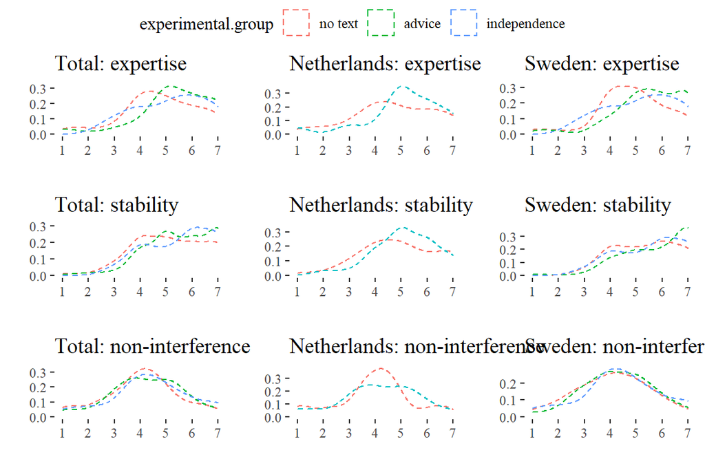

```r
ggarrange(df.check %>% ggplot(aes(x= credibility.expert, color = experimental.group)) +
 geom_density(alpha= .1, linetype= "dashed") + theme(axis.title = element_blank()) + labs(y = "", title = "Total: expertise") +  scale_x_continuous(name="", breaks = 1:7) + scale_fill_manual(name = "Condition") +  scale_fill_viridis_d(name = "Condition") +
  theme_tufte(),

 df.check %>% filter(country == "NL") %>% ggplot(aes(x= credibility.expert, color = experimental.group)) +
 geom_density(alpha= .1, linetype= "dashed") + theme(axis.title = element_blank()) + labs(y = "", title = "Netherlands: expertise") +  scale_x_continuous(name="", breaks = 1:7) + scale_fill_manual(name = "Condition") +  scale_fill_viridis_d(name = "Condition") +
  theme_tufte(),

  df.check %>% filter(country == "SE") %>% ggplot(aes(x= credibility.expert, color = experimental.group)) +
 geom_density(alpha= .1, linetype= "dashed") + theme(axis.title = element_blank()) + labs(y = "", title = "Sweden: expertise") +  scale_x_continuous(name="", breaks = 1:7) + scale_fill_manual(name = "Condition") +  scale_fill_viridis_d(name = "Condition") +
  theme_tufte(),

 df.check %>% ggplot(aes(x= credibility.stability, color = experimental.group)) +
 geom_density(alpha= .1, linetype= "dashed") + theme(axis.title = element_blank()) + labs(y = "", title = "Total: stability") +  scale_x_continuous(name="", breaks = 1:7) + scale_fill_manual(name = "Condition") +  scale_fill_viridis_d(name = "Condition") +
  theme_tufte(),

 df.check %>% filter(country == "NL") %>% ggplot(aes(x= credibility.stability, color = experimental.group)) +
 geom_density(alpha= .1, linetype= "dashed") + theme(axis.title = element_blank()) + labs(y = "", title = "Netherlands: stability") +  scale_x_continuous(name="", breaks = 1:7) + scale_fill_manual(name = "Condition") +  scale_fill_viridis_d(name = "Condition") +
  theme_tufte(),

  df.check %>% filter(country == "SE") %>% ggplot(aes(x= credibility.stability, color = experimental.group)) +
 geom_density(alpha= .1, linetype= "dashed") + theme(axis.title = element_blank()) + labs(y = "", title = "Sweden: stability") +  scale_x_continuous(name="", breaks = 1:7) + scale_fill_manual(name = "Condition") +  scale_fill_viridis_d(name = "Condition") +
  theme_tufte(),

 df.check %>% ggplot(aes(x= credibility.noninterference, color = experimental.group)) +
 geom_density(alpha= .1, linetype= "dashed") + theme(axis.title = element_blank()) + labs(y = "", title = "Total: non-interference") +  scale_x_continuous(name="", breaks = 1:7) + scale_fill_manual(name = "Condition") +  scale_fill_viridis_d(name = "Condition") +
  theme_tufte(),

 df.check %>% filter(country == "NL") %>% ggplot(aes(x= credibility.noninterference, color = experimental.group)) +
 geom_density(alpha= .1, linetype= "dashed") + theme(axis.title = element_blank()) + labs(y = "", title = "Netherlands: non-interference") +  scale_x_continuous(name="", breaks = 1:7) + scale_fill_manual(name = "Condition") +  scale_fill_viridis_d(name = "Condition") +
  theme_tufte(),

  df.check %>% filter(country == "SE") %>% ggplot(aes(x= credibility.noninterference, color = experimental.group)) +
 geom_density(alpha= .1, linetype= "dashed") + theme(axis.title = element_blank()) + labs(y = "", title = "Sweden: non-interference") +  scale_x_continuous(name="", breaks = 1:7) + scale_fill_manual(name = "Condition") +  scale_fill_viridis_d(name = "Condition") +
  theme_tufte(),
  ncol = 3, nrow = 3, common.legend = TRUE)
```

### 4.4.5 Expertise

**Regression**

```r
reg.credibility.expertise.total.check <- lm(credibility.expert ~  experimental.group,
                    data = df.check,
                    na.action = na.omit)

reg.credibility.expertise.SE.check <- lm(credibility.expert ~ experimental.group,
                    data =  df.check.SE,
                    na.action = na.omit)

reg.credibility.NL.check <- lm(credibility.expert ~  experimental.group,
                    data =   df.check.NL,
                    na.action = na.omit)

tab_model(reg.credibility.expertise.total.check, reg.credibility.expertise.SE.check, reg.credibility.NL.check, dv.labels = c("Expertise - Total", "Expertise - SE", "Expertise - NL"), title = "Expertise - filter: manipulation check", show.ci = FALSE)
```

Expertise - filter: manipulation check

|  | Expertise - Total |  | Expertise - SE |  | Expertise - NL |  |
| --- | --- | --- | --- | --- | --- | --- |
| Predictors | Estimates | p | Estimates | p | Estimates | p |
| (Intercept) | 4.79 | **<0.001** | 4.85 | **<0.001** | 4.72 | **<0.001** |
| experimental.group [advice] | 0.53 | **0.007** | 0.64 | **0.014** | 0.37 | 0.213 |
| experimental.group [independence] | 0.37 | 0.126 | 0.31 | 0.262 |  |  |
| Observations | 271 |  | 166 |  | 105 |  |
| R<sup>2</sup> / R<sup>2</sup> adjusted | 0.027 / 0.020 |  | 0.037 / 0.025 |  | 0.015 / 0.005 |  |

**Total**

```r
tadaa_aov(credibility.expert ~ experimental.group, data = df.check, print = "markdown")
```

Table 28: **One-Way ANOVA**: Using Type III Sum of Squares

| Term | df | SS | MS | F | p | $\eta^2$ | Cohen’s f |
| --- | --- | --- | --- | --- | --- | --- | --- |
| experimental.group | 2 | 14.83 | 7.41 | 3.72 | < .05 | 0.03 | 0.17 |
| Residuals | 268 | 534.42 | 1.99 |  |  |  |  |
| Total | 270 | 549.25 | 9.41 |  |  |  |  |

**Sweden**

```r
tadaa_aov(credibility.expert ~ experimental.group, data = df.check.SE, print = "markdown")
```

Table 29: **One-Way ANOVA**: Using Type III Sum of Squares

| Term | df | SS | MS | F | p | $\eta^2$ | Cohen’s f |
| --- | --- | --- | --- | --- | --- | --- | --- |
| experimental.group | 2 | 11.27 | 5.63 | 3.12 | < .05 | 0.04 | 0.2 |
| Residuals | 163 | 293.92 | 1.8 |  |  |  |  |
| Total | 165 | 305.19 | 7.44 |  |  |  |  |

**Netherlands**

```r
tadaa_t.test(data = df.check.NL, response = credibility.expert, group = experimental.group, print = "markdown")
```

Table 30: **Welch Two Sample t-test** with alternative hypothesis: $\mu_1 \neq \mu_2$

| Diff | $\mu_1$ no text | $\mu_2$ advice | t | SE | df | $CI_{95\%}$ | p | Cohen's d |
| --- | --- | --- | --- | --- | --- | --- | --- | --- |
| -0.37 | 4.72 | 5.09 | -1.24 | 0.3 | 94.49 | (-0.97 - 0.22) | .218 | -0.25 |

### 4.4.6 Stability

**Regression**

```r
reg.credibility.stability.total.check <- lm(credibility.stability ~  experimental.group,
                    data = df.check,
                    na.action = na.omit)

reg.credibility.stability.SE.check <- lm(credibility.stability ~ experimental.group,
                    data =  df.check.SE,
                    na.action = na.omit)

reg.stability.NL.check <- lm(credibility.stability ~  experimental.group,
                    data =   df.check.NL,
                    na.action = na.omit)

tab_model(reg.credibility.stability.total.check , reg.credibility.stability.SE.check , reg.stability.NL.check , dv.labels = c("Stability - Total", "Stability - SE", "Stability - NL"), title = "Stability - filter: manipulation check", show.ci = FALSE)
```

Stability - filter: manipulation check

|  | Stability - Total |  | Stability - SE |  | Stability - NL |  |
| --- | --- | --- | --- | --- | --- | --- |
| Predictors | Estimates | p | Estimates | p | Estimates | p |
| (Intercept) | 5.15 | **<0.001** | 5.39 | **<0.001** | 4.94 | **<0.001** |
| experimental.group [advice] | 0.37 | **0.040** | 0.44 | 0.075 | 0.24 | 0.371 |
| experimental.group [independence] | 0.39 | 0.086 | 0.16 | 0.536 |  |  |
| Observations | 271 |  | 166 |  | 105 |  |
| R<sup>2</sup> / R<sup>2</sup> adjusted | 0.018 / 0.011 |  | 0.021 / 0.009 |  | 0.008 / -0.002 |  |

**Total**

```r
tadaa_aov(credibility.stability ~ experimental.group, data = df.check, print = "markdown")
```

Table 31: **One-Way ANOVA**: Using Type III Sum of Squares

| Term | df | SS | MS | F | p | $\eta^2$ | Cohen’s f |
| --- | --- | --- | --- | --- | --- | --- | --- |
| experimental.group | 2 | 8.72 | 4.36 | 2.5 | .084 | 0.02 | 0.14 |
| Residuals | 268 | 466.63 | 1.74 |  |  |  |  |
| Total | 270 | 475.35 | 6.1 |  |  |  |  |

**Sweden**

```r
tadaa_aov(credibility.stability ~ experimental.group, data = df.check.SE, print = "markdown")
```

Table 32: **One-Way ANOVA**: Using Type III Sum of Squares

| Term | df | SS | MS | F | p | $\eta^2$ | Cohen’s f |
| --- | --- | --- | --- | --- | --- | --- | --- |
| experimental.group | 2 | 5.61 | 2.81 | 1.74 | .179 | 0.02 | 0.15 |
| Residuals | 163 | 263.48 | 1.62 |  |  |  |  |
| Total | 165 | 269.09 | 4.42 |  |  |  |  |

**Netherlands**

```r
tadaa_t.test(data = df.check.NL, response = credibility.stability, group = experimental.group, print = "markdown")
```

Table 33: **Welch Two Sample t-test** with alternative hypothesis: $\mu_1 \neq \mu_2$

| Diff | $\mu_1$ no text | $\mu_2$ advice | t | SE | df | $CI_{95\%}$ | p | Cohen's d |
| --- | --- | --- | --- | --- | --- | --- | --- | --- |
| -0.24 | 4.94 | 5.17 | -0.88 | 0.27 | 87.42 | (-0.77 - 0.3) | .382 | -0.18 |

### 4.4.7 Non-interference

**Regression**

```r
reg.credibility.noninterference.total.check <- lm(credibility.noninterference ~  experimental.group,
                    data = df.check,
                    na.action = na.omit)

reg.credibility.noninterference.SE.check <- lm(credibility.noninterference ~ experimental.group,
                    data =  df.check.SE,
                    na.action = na.omit)

reg.noninterference.NL.check <- lm(credibility.noninterference ~  experimental.group,
                    data =   df.check.NL,
                    na.action = na.omit)

tab_model(reg.credibility.noninterference.total.check, reg.credibility.noninterference.SE.check, reg.noninterference.NL.check, dv.labels = c("Non-interference - Total", "Non-interference - SE", "Non-interference - NL"), title = "Non-interference - filter: manipulation check", show.ci = FALSE)
```

Non-interference - filter: manipulation check

|  | Non-interference - Total |  | Non-interference - SE |  | Non-interference - NL |  |
| --- | --- | --- | --- | --- | --- | --- |
| Predictors | Estimates | p | Estimates | p | Estimates | p |
| (Intercept) | 4.05 | **<0.001** | 4.10 | **<0.001** | 4.00 | **<0.001** |
| experimental.group [advice] | 0.19 | 0.341 | 0.18 | 0.509 | 0.18 | 0.526 |
| experimental.group [independence] | 0.32 | 0.194 | 0.27 | 0.350 |  |  |
| Observations | 271 |  | 166 |  | 105 |  |
| R<sup>2</sup> / R<sup>2</sup> adjusted | 0.007 / -0.001 |  | 0.005 / -0.007 |  | 0.004 / -0.006 |  |

**Total**

```r
tadaa_aov(credibility.noninterference ~ experimental.group, data = df.check, print = "markdown")
```

Table 34: **One-Way ANOVA**: Using Type III Sum of Squares

| Term | df | SS | MS | F | p | $\eta^2$ | Cohen’s f |
| --- | --- | --- | --- | --- | --- | --- | --- |
| experimental.group | 2 | 3.83 | 1.92 | 0.93 | .397 | 0.01 | 0.08 |
| Residuals | 268 | 554.3 | 2.07 |  |  |  |  |
| Total | 270 | 558.13 | 3.98 |  |  |  |  |

**Sweden**

```r
tadaa_aov(credibility.noninterference ~ experimental.group, data = df.check.SE, print = "markdown")
```

Table 35: **One-Way ANOVA**: Using Type III Sum of Squares

| Term | df | SS | MS | F | p | $\eta^2$ | Cohen’s f |
| --- | --- | --- | --- | --- | --- | --- | --- |
| experimental.group | 2 | 1.83 | 0.91 | 0.45 | .638 | 0.01 | 0.07 |
| Residuals | 163 | 330.86 | 2.03 |  |  |  |  |
| Total | 165 | 332.69 | 2.94 |  |  |  |  |

**Netherlands**

```r
tadaa_t.test(data = df.check.NL, response = credibility.noninterference, group = experimental.group, print = "markdown")
```

Table 36: **Welch Two Sample t-test** with alternative hypothesis: $\mu_1 \neq \mu_2$

| Diff | $\mu_1$ no text | $\mu_2$ advice | t | SE | df | $CI_{95\%}$ | p | Cohen's d |
| --- | --- | --- | --- | --- | --- | --- | --- | --- |
| -0.18 | 4 | 4.18 | -0.64 | 0.29 | 100.03 | (-0.75 - 0.39) | .524 | -0.13 |

## 4.5 Only those who spent more time on the introduction page of the case than the median participant

### 4.5.1 Histograms

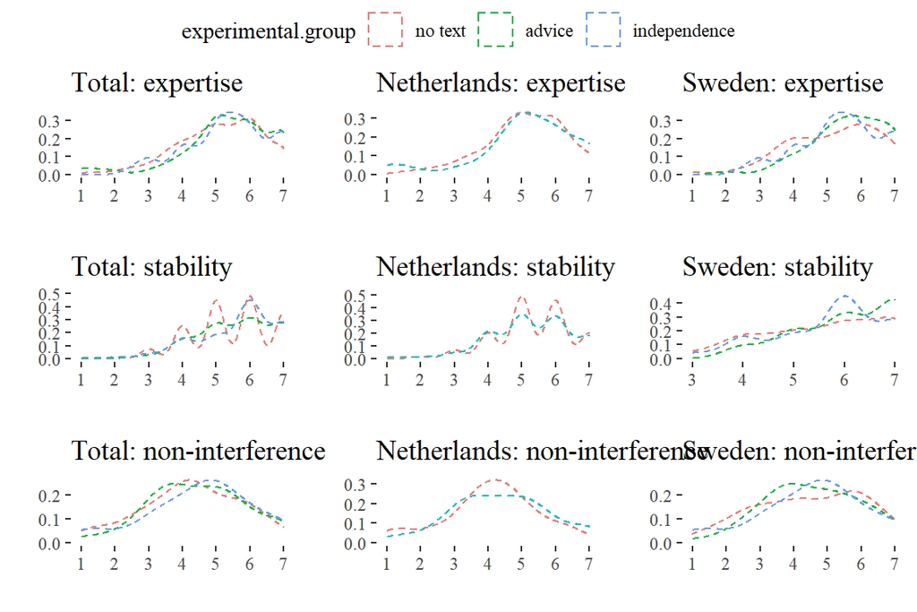

```r
ggarrange(df.intro  %>% ggplot(aes(x= credibility.expert, color = experimental.group)) +
 geom_density(alpha= .1, linetype= "dashed") + theme(axis.title = element_blank()) + labs(y = "", title = "Total: expertise") +  scale_x_continuous(name="", breaks = 1:7) + scale_fill_manual(name = "Condition") +  scale_fill_viridis_d(name = "Condition") +
  theme_tufte(),

df.intro.NL %>% ggplot(aes(x= credibility.expert, color = experimental.group)) +
 geom_density(alpha= .1, linetype= "dashed") + theme(axis.title = element_blank()) + labs(y = "", title = "Netherlands: expertise") +  scale_x_continuous(name="", breaks = 1:7) + scale_fill_manual(name = "Condition") +  scale_fill_viridis_d(name = "Condition") +
  theme_tufte(),

df.intro.SE %>% ggplot(aes(x= credibility.expert, color = experimental.group)) +
 geom_density(alpha= .1, linetype= "dashed") + theme(axis.title = element_blank()) + labs(y = "", title = "Sweden: expertise") +  scale_x_continuous(name="", breaks = 1:7) + scale_fill_manual(name = "Condition") +  scale_fill_viridis_d(name = "Condition") +
  theme_tufte(),

df.intro %>% ggplot(aes(x= credibility.stability, color = experimental.group)) +
 geom_density(alpha= .1, linetype= "dashed") + theme(axis.title = element_blank()) + labs(y = "", title = "Total: stability") +  scale_x_continuous(name="", breaks = 1:7) + scale_fill_manual(name = "Condition") +  scale_fill_viridis_d(name = "Condition") +
  theme_tufte(),

 df.intro.NL %>% ggplot(aes(x= credibility.stability, color = experimental.group)) +
 geom_density(alpha= .1, linetype= "dashed") + theme(axis.title = element_blank()) + labs(y = "", title = "Netherlands: stability") +  scale_x_continuous(name="", breaks = 1:7) + scale_fill_manual(name = "Condition") +  scale_fill_viridis_d(name = "Condition") +
  theme_tufte(),

  df.intro.SE %>% ggplot(aes(x= credibility.stability, color = experimental.group)) +
 geom_density(alpha= .1, linetype= "dashed") + theme(axis.title = element_blank()) + labs(y = "", title = "Sweden: stability") +  scale_x_continuous(name="", breaks = 1:7) + scale_fill_manual(name = "Condition") +  scale_fill_viridis_d(name = "Condition") +
  theme_tufte(),

 df.intro %>% ggplot(aes(x= credibility.noninterference, color = experimental.group)) +
 geom_density(alpha= .1, linetype= "dashed") + theme(axis.title = element_blank()) + labs(y = "", title = "Total: non-interference") +  scale_x_continuous(name="", breaks = 1:7) + scale_fill_manual(name = "Condition") +  scale_fill_viridis_d(name = "Condition") +
  theme_tufte(),

df.intro.NL %>% ggplot(aes(x= credibility.noninterference, color = experimental.group)) +
 geom_density(alpha= .1, linetype= "dashed") + theme(axis.title = element_blank()) + labs(y = "", title = "Netherlands: non-interference") +  scale_x_continuous(name="", breaks = 1:7) + scale_fill_manual(name = "Condition") +  scale_fill_viridis_d(name = "Condition") +
  theme_tufte(),

df.intro.SE %>% ggplot(aes(x= credibility.noninterference, color = experimental.group)) +
 geom_density(alpha= .1, linetype= "dashed") + theme(axis.title = element_blank()) + labs(y = "", title = "Sweden: non-interference") +  scale_x_continuous(name="", breaks = 1:7) + scale_fill_manual(name = "Condition") +  scale_fill_viridis_d(name = "Condition") +
  theme_tufte(),
  ncol = 3, nrow = 3, common.legend = TRUE)
```

### 4.5.2 Expertise

**Regression**

```r
reg.credibility.expertise.total.intro <- lm(credibility.expert ~  experimental.group,
                    data = df.intro,
                    na.action = na.omit)

reg.credibility.expertise.SE.intro <- lm(credibility.expert ~ experimental.group,
                    data =  df.intro.SE,
                    na.action = na.omit)

reg.credibility.NL.intro <- lm(credibility.expert ~  experimental.group,
                    data =   df.intro.NL,
                    na.action = na.omit)

tab_model(reg.credibility.expertise.total.intro , reg.credibility.expertise.SE.intro, reg.credibility.NL.intro, dv.labels = c("Expertise - Total", "Expertise - SE", "Expertise - NL"), title = "Expertise - filter: introduction of case", show.ci = FALSE)
```

Expertise - filter: introduction of case

|  | Expertise - Total |  | Expertise - SE |  | Expertise - NL |  |
| --- | --- | --- | --- | --- | --- | --- |
| Predictors | Estimates | p | Estimates | p | Estimates | p |
| (Intercept) | 5.14 | **<0.001** | 5.19 | **<0.001** | 5.10 | **<0.001** |
| experimental.group [advice] | 0.18 | 0.241 | 0.44 | **0.050** | -0.01 | 0.970 |
| experimental.group [independence] | 0.22 | 0.286 | 0.16 | 0.465 |  |  |
| Observations | 340 |  | 179 |  | 161 |  |
| R<sup>2</sup> / R<sup>2</sup> adjusted | 0.006 / -0.000 |  | 0.022 / 0.011 |  | 0.000 / -0.006 |  |

**Total**

```r
tadaa_aov(credibility.expert ~ experimental.group, data = df.intro, print = "markdown")
```

Table 37: **One-Way ANOVA**: Using Type III Sum of Squares

| Term | df | SS | MS | F | p | $\eta^2$ | Cohen’s f |
| --- | --- | --- | --- | --- | --- | --- | --- |
| experimental.group | 2 | 3.11 | 1.56 | 0.93 | .394 | 0.01 | 0.07 |
| Residuals | 337 | 561.63 | 1.67 |  |  |  |  |
| Total | 339 | 564.75 | 3.22 |  |  |  |  |

**Sweden**

```r
tadaa_aov(credibility.expert ~ experimental.group, data = df.intro.SE, print = "markdown")
```

Table 38: **One-Way ANOVA**: Using Type III Sum of Squares

| Term | df | SS | MS | F | p | $\eta^2$ | Cohen’s f |
| --- | --- | --- | --- | --- | --- | --- | --- |
| experimental.group | 2 | 5.96 | 2.98 | 1.97 | .143 | 0.02 | 0.15 |
| Residuals | 176 | 266.58 | 1.51 |  |  |  |  |
| Total | 178 | 272.54 | 4.49 |  |  |  |  |

**Netherlands**

```r
tadaa_t.test(data = df.intro.NL, response = credibility.expert, group = experimental.group, print = "markdown")
```

Table 39: **Welch Two Sample t-test** with alternative hypothesis: $\mu_1 \neq \mu_2$

| Diff | $\mu_1$ no text | $\mu_2$ advice | t | SE | df | $CI_{95\%}$ | p | Cohen's d |
| --- | --- | --- | --- | --- | --- | --- | --- | --- |
| 0.01 | 5.1 | 5.09 | 0.04 | 0.21 | 143.91 | (-0.42 - 0.43) | .971 | 0.01 |

### 4.5.3 Stability

**Regression**

```r
reg.credibility.stability.total.intro <- lm(credibility.stability ~  experimental.group,
                    data = df.intro,
                    na.action = na.omit)

reg.credibility.stability.SE.intro <- lm(credibility.stability ~ experimental.group,
                    data = df.intro.SE,
                    na.action = na.omit)

reg.stability.NL.intro <- lm(credibility.stability ~  experimental.group,
                    data =   df.intro.NL,
                    na.action = na.omit)

tab_model(reg.credibility.stability.total.intro, reg.credibility.stability.SE.intro, reg.stability.NL.intro , dv.labels = c("Stability - Total", "Stability - SE", "Stability - NL"), title = "Stability -  filter: introduction of case", show.ci = FALSE)
```

Stability - filter: introduction of case

|  | Stability - Total |  | Stability - SE |  | Stability - NL |  |
| --- | --- | --- | --- | --- | --- | --- |
| Predictors | Estimates | p | Estimates | p | Estimates | p |
| (Intercept) | 5.46 | **<0.001** | 5.63 | **<0.001** | 5.33 | **<0.001** |
| experimental.group [advice] | 0.12 | 0.379 | 0.41 | **0.046** | -0.08 | 0.669 |
| experimental.group [independence] | 0.24 | 0.199 | 0.07 | 0.732 |  |  |
| Observations | 340 |  | 179 |  | 161 |  |
| R<sup>2</sup> / R<sup>2</sup> adjusted | 0.005 / -0.000 |  | 0.025 / 0.014 |  | 0.001 / -0.005 |  |

**Total**

```r
tadaa_aov(credibility.stability ~ experimental.group, data = df.intro, print = "markdown")
```

Table 40: **One-Way ANOVA**: Using Type III Sum of Squares

| Term | df | SS | MS | F | p | $\eta^2$ | Cohen’s f |
| --- | --- | --- | --- | --- | --- | --- | --- |
| experimental.group | 2 | 2.56 | 1.28 | 0.93 | .395 | 0.01 | 0.07 |
| Residuals | 337 | 463.69 | 1.38 |  |  |  |  |
| Total | 339 | 466.25 | 2.66 |  |  |  |  |

**Sweden**

```r
tadaa_aov(credibility.stability ~ experimental.group, data = df.intro.SE, print = "markdown")
```

Table 41: **One-Way ANOVA**: Using Type III Sum of Squares

| Term | df | SS | MS | F | p | $\eta^2$ | Cohen’s f |
| --- | --- | --- | --- | --- | --- | --- | --- |
| experimental.group | 2 | 5.62 | 2.81 | 2.23 | .11 | 0.02 | 0.16 |
| Residuals | 176 | 221.44 | 1.26 |  |  |  |  |
| Total | 178 | 227.06 | 4.07 |  |  |  |  |

**Netherlands**

```r
tadaa_t.test(data = df.intro.NL, response = credibility.stability, group = experimental.group, print = "markdown")
```

Table 42: **Welch Two Sample t-test** with alternative hypothesis: $\mu_1 \neq \mu_2$

| Diff | $\mu_1$ no text | $\mu_2$ advice | t | SE | df | $CI_{95\%}$ | p | Cohen's d |
| --- | --- | --- | --- | --- | --- | --- | --- | --- |
| 0.08 | 5.33 | 5.25 | 0.43 | 0.19 | 151.05 | (-0.29 - 0.45) | .671 | 0.07 |

### 4.5.4 Non-interference

**Regression**

```r
reg.credibility.noninterference.total.intro <- lm(credibility.noninterference ~  experimental.group,
                    data = df.intro,
                    na.action = na.omit)

reg.credibility.noninterference.SE.intro <- lm(credibility.noninterference ~ experimental.group,
                    data =  df.intro.SE,
                    na.action = na.omit)

reg.noninterference.NL.intro <- lm(credibility.noninterference ~  experimental.group,
                    data = df.intro.NL,
                    na.action = na.omit)

tab_model(reg.credibility.noninterference.total.intro, reg.credibility.noninterference.SE.intro, reg.noninterference.NL.intro, dv.labels = c("Non-interference - Total", "Non-interference - SE", "Non-interference - NL"), title = "Non-interference - filter: introduction of case", show.ci = FALSE)
```

Non-interference - filter: introduction of case

|  | Non-interference - Total |  | Non-interference - SE |  | Non-interference - NL |  |
| --- | --- | --- | --- | --- | --- | --- |
| Predictors | Estimates | p | Estimates | p | Estimates | p |
| (Intercept) | 4.26 | **<0.001** | 4.46 | **<0.001** | 4.09 | **<0.001** |
| experimental.group [advice] | 0.19 | 0.293 | 0.07 | 0.809 | 0.28 | 0.208 |
| experimental.group [independence] | 0.24 | 0.293 | 0.04 | 0.893 |  |  |
| Observations | 340 |  | 179 |  | 161 |  |
| R<sup>2</sup> / R<sup>2</sup> adjusted | 0.005 / -0.001 |  | 0.000 / -0.011 |  | 0.010 / 0.004 |  |

**Total**

```r
tadaa_aov(credibility.noninterference ~ experimental.group, data = df.intro, print = "markdown")
```

Table 43: **One-Way ANOVA**: Using Type III Sum of Squares

| Term | df | SS | MS | F | p | $\eta^2$ | Cohen’s f |
| --- | --- | --- | --- | --- | --- | --- | --- |
| experimental.group | 2 | 3.58 | 1.79 | 0.82 | .441 | 0 | 0.07 |
| Residuals | 337 | 736.66 | 2.19 |  |  |  |  |
| Total | 339 | 740.24 | 3.98 |  |  |  |  |

**Sweden**

```r
tadaa_aov(credibility.noninterference ~ experimental.group, data = df.intro.SE, print = "markdown")
```

Table 44: **One-Way ANOVA**: Using Type III Sum of Squares

| Term | df | SS | MS | F | p | $\eta^2$ | Cohen’s f |
| --- | --- | --- | --- | --- | --- | --- | --- |
| experimental.group | 2 | 0.14 | 0.07 | 0.03 | .971 | 0 | 0.02 |
| Residuals | 176 | 411.27 | 2.34 |  |  |  |  |
| Total | 178 | 411.41 | 2.41 |  |  |  |  |

**Netherlands**

```r
tadaa_t.test(data = df.intro.NL, response = credibility.noninterference, group = experimental.group, print = "markdown")
```

Table 45: **Welch Two Sample t-test** with alternative hypothesis: $\mu_1 \neq \mu_2$

| Diff | $\mu_1$ no text | $\mu_2$ advice | t | SE | df | $CI_{95\%}$ | p | Cohen's d |
| --- | --- | --- | --- | --- | --- | --- | --- | --- |
| -0.28 | 4.09 | 4.38 | -1.26 | 0.22 | 155.04 | (-0.73 - 0.16) | .209 | -0.2 |

## 4.6 Explaining credibility

```r
library(rockchalk)
model.credibility.index <- lm(credibility.index  ~ perceived.independence.reversed + trust.politicians + trust.scientist + trust.EC + trust.health.authorities + interpersonal.trust + benefits.vaccines + credibility.EMA + credibility.post + familiarity.EMA + familiarity.advice +  political.ideology + consequences.health + consequences.economic + EU.integration + private.providers + knowledge +  experimental.group + female + poly(age, 2) + healthcare + income + education.recoded + perceived.independence.reversed:benefits.vaccines + benefits.vaccines:experimental.group,
                    data = df.def.error,
                    na.action = na.omit) %>% meanCenter()

  model.credibility.stability <- lm(credibility.stability  ~ perceived.independence.reversed + trust.politicians + trust.scientist + trust.EC + trust.health.authorities + interpersonal.trust + benefits.vaccines + credibility.EMA + credibility.post + familiarity.EMA + familiarity.advice +  political.ideology + consequences.health + consequences.economic + EU.integration + private.providers + knowledge +  experimental.group + female + poly(age, 2) + healthcare + income + education.recoded + perceived.independence.reversed:benefits.vaccines + benefits.vaccines:experimental.group,
                    data = df.def.error,
                    na.action = na.omit) %>% meanCenter()

model.credibility.expertise <- lm(credibility.expert ~ perceived.independence.reversed + trust.politicians + trust.scientist + trust.EC + trust.health.authorities + interpersonal.trust + benefits.vaccines + credibility.EMA + credibility.post + familiarity.EMA + familiarity.advice +  political.ideology + consequences.health + consequences.economic + EU.integration + private.providers + knowledge +  experimental.group + female + poly(age, 2) + healthcare + income + education.recoded + perceived.independence.reversed:benefits.vaccines + benefits.vaccines:experimental.group,
                    data = df.def.error,
                    na.action = na.omit) %>% meanCenter()

model.credibility.noninterference <- lm(credibility.noninterference ~ perceived.independence.reversed + trust.politicians + trust.scientist + trust.EC + trust.health.authorities + interpersonal.trust + benefits.vaccines + credibility.EMA + credibility.post + familiarity.EMA + familiarity.advice +  political.ideology + consequences.health + consequences.economic + EU.integration + private.providers + knowledge +  experimental.group + female + poly(age, 2) + healthcare + income + education.recoded + perceived.independence.reversed:benefits.vaccines +  benefits.vaccines:experimental.group,
                    data = df.def.error,
                    na.action = na.omit) %>% meanCenter()

tab_model(model.credibility.index, model.credibility.stability, model.credibility.expertise, model.credibility.noninterference, dv.labels = c("Credibility index", "Stability", "Expertise", "Non-interference"), title = "Explaining credibility - index and dimensions", show.ci = FALSE)
```

Explaining credibility - index and dimensions

|  | Credibility index |  | Stability |  | Expertise |  | Non-interference |  |
| --- | --- | --- | --- | --- | --- | --- | --- | --- |
| Predictors | Estimates | p | Estimates | p | Estimates | p | Estimates | p |
| (Intercept) | 1.69 | **<0.001** | 3.66 | **<0.001** | 1.06 | **0.007** | 1.45 | **0.004** |
| perceived.independence.reversedc | 0.14 | **<0.001** | -0.05 | 0.228 | 0.01 | 0.766 | 0.30 | **<0.001** |
| trust.politicians | 0.01 | 0.772 | -0.01 | 0.810 | 0.01 | 0.788 | 0.01 | 0.737 |
| trust.scientist | 0.08 | **0.016** | 0.16 | **0.008** | 0.17 | **<0.001** | -0.00 | 0.974 |
| trust.EC | 0.03 | 0.459 | 0.06 | 0.401 | 0.03 | 0.498 | 0.02 | 0.766 |
| trust.health.authorities | 0.01 | 0.821 | -0.00 | 0.989 | 0.01 | 0.809 | 0.01 | 0.858 |
| interpersonal.trust | 0.01 | 0.530 | -0.05 | 0.248 | 0.00 | 0.993 | 0.05 | 0.206 |
| benefits.vaccinesc | 0.16 | **0.001** | 0.08 | 0.346 | 0.11 | **0.043** | 0.22 | **0.002** |
| credibility.EMA | -0.00 | 1.000 | -0.09 | 0.176 | -0.02 | 0.624 | 0.05 | 0.438 |
| credibility.post | 0.51 | **<0.001** | 0.33 | **<0.001** | 0.61 | **<0.001** | 0.49 | **<0.001** |
| familiarity.EMA | -0.06 | 0.078 | -0.15 | **0.010** | -0.02 | 0.594 | -0.05 | 0.300 |
| familiarity.advice | 0.05 | 0.109 | 0.17 | **0.001** | 0.00 | 0.953 | 0.04 | 0.417 |
| political.ideology | -0.01 | 0.608 | -0.00 | 0.943 | 0.01 | 0.756 | -0.03 | 0.423 |
| consequences.health | 0.01 | 0.589 | -0.03 | 0.413 | 0.02 | 0.365 | 0.02 | 0.572 |
| consequences.economic | -0.03 | 0.166 | -0.02 | 0.672 | 0.01 | 0.602 | -0.06 | 0.056 |
| EU.integration | 0.02 | 0.365 | -0.04 | 0.368 | 0.02 | 0.504 | 0.05 | 0.232 |
| private.providers | -0.04 | **0.043** | -0.07 | 0.066 | -0.00 | 0.905 | -0.06 | 0.061 |
| knowledge | 0.09 | 0.166 | 0.03 | 0.827 | -0.05 | 0.563 | 0.21 | **0.044** |
| experimental.group [advice] | 0.06 | 0.452 | 0.11 | 0.450 | 0.20 | **0.032** | -0.05 | 0.686 |
| experimental.group [independence] | -0.00 | 0.966 | 0.09 | 0.545 | 0.10 | 0.292 | -0.10 | 0.408 |
| female | 0.16 | **0.022** | -0.20 | 0.122 | 0.17 | **0.042** | 0.28 | **0.011** |
| age [1st degree] | 2.11 | **0.003** | 0.93 | 0.455 | 1.99 | **0.015** | 2.58 | **0.016** |
| age [2nd degree] | 0.02 | 0.972 | -1.13 | 0.345 | 0.62 | 0.431 | 0.01 | 0.990 |
| healthcare [yes] | -0.24 | 0.056 | -0.54 | **0.015** | -0.01 | 0.944 | -0.29 | 0.129 |
| income200K-250K SEK | 0.11 | 0.351 | 0.16 | 0.441 | -0.10 | 0.475 | 0.23 | 0.200 |
| income250K-300K SEK | -0.17 | 0.219 | -0.16 | 0.511 | -0.21 | 0.174 | -0.14 | 0.508 |
| income300K-350K SEK | 0.03 | 0.829 | 0.25 | 0.319 | 0.05 | 0.745 | -0.06 | 0.786 |
| income350K-400K SEK | -0.14 | 0.339 | 0.07 | 0.769 | 0.00 | 0.988 | -0.30 | 0.171 |
| income400K-450K SEK | 0.15 | 0.265 | 0.32 | 0.182 | 0.07 | 0.662 | 0.15 | 0.473 |
| income450K-500K SEK | 0.13 | 0.362 | -0.11 | 0.658 | 0.09 | 0.560 | 0.23 | 0.285 |
| income [500K> SEK] | 0.07 | 0.463 | 0.09 | 0.595 | 0.09 | 0.411 | 0.05 | 0.738 |
| education.recoded [2. Grundskola (9 år)] | -0.29 | 0.253 | 0.25 | 0.584 | -0.56 | 0.059 | -0.29 | 0.455 |
| education.recoded [3. Gymnasiestudier (mindre än 3 år)] | -0.21 | 0.381 | 0.05 | 0.900 | -0.54 | 0.051 | -0.07 | 0.839 |
| education.recoded [4. Gymnasiestudier (3 år)] | -0.01 | 0.959 | -0.09 | 0.839 | -0.21 | 0.458 | 0.14 | 0.697 |
| education.recoded [5. Eftergymnasial utbildning (mindre än 3 år)] | -0.21 | 0.385 | 0.30 | 0.484 | -0.54 | 0.053 | -0.16 | 0.670 |
| education.recoded [6. Eftergymnasial utbildning (3 år eller mer)] | -0.18 | 0.454 | 0.39 | 0.357 | -0.25 | 0.365 | -0.32 | 0.380 |
| education.recoded [7. Forskarutbildning] | 0.10 | 0.758 | 0.61 | 0.275 | -0.04 | 0.904 | 0.02 | 0.969 |
| education.recoded [8. Annan] | -0.34 | 0.297 | 0.53 | 0.365 | -0.50 | 0.188 | -0.52 | 0.295 |
| perceived.independence.reversedc * benefits.vaccinesc | -0.02 | 0.116 | 0.04 | 0.136 | -0.04 | **0.027** | -0.04 | 0.131 |
| benefits.vaccinesc * experimental.group [advice] | -0.08 | 0.180 | 0.18 | 0.069 | 0.04 | 0.520 | -0.24 | **0.006** |
| benefits.vaccinesc * experimental.group [independence] | -0.01 | 0.815 | -0.03 | 0.814 | 0.04 | 0.524 | -0.05 | 0.590 |
| Observations | 365 |  | 365 |  | 365 |  | 365 |  |
| R<sup>2</sup> / R<sup>2</sup> adjusted | 0.766 / 0.737 |  | 0.382 / 0.306 |  | 0.765 / 0.736 |  | 0.632 / 0.586 |  |

# 5 Pre-post

## 5.1 Correlation matrix

```r
df.def.error %>%
  select(credibility.EMA,
         credibility.post,
         credibility.expert,
         credibility.noninterference,
         credibility.stability,
         credibility.index,
         perceived.independence.reversed,
         intent.vaccine,
         ) %>%
  tab_corr(triangle="lower",
           remove.spaces=T,
           p.numeric = T,
           fade.ns = T,
           digits = 2,
           na.deletion="pairwise",
           title = "Correlation matrix")
```

Correlation matrix

|  | credibility.EMA | credibility.post | credibility.expert | credibility.noninterference | credibility.stability | credibility.index | perceived.independence.reversed | intent.vaccine |
| --- | --- | --- | --- | --- | --- | --- | --- | --- |
| credibility.EMA |  |  |  |  |  |  |  |  |
| credibility.post | 0.68 (<.001) |  |  |  |  |  |  |  |
| credibility.expert | 0.61 (<.001) | 0.83 (<.001) |  |  |  |  |  |  |
| credibility.noninterference | 0.49 (<.001) | 0.66 (<.001) | 0.64 (<.001) |  |  |  |  |  |
| credibility.stability | 0.34 (<.001) | 0.47 (<.001) | 0.50 (<.001) | 0.30 (<.001) |  |  |  |  |
| credibility.index | 0.60 (<.001) | 0.81 (<.001) | 0.88 (<.001) | 0.91 (<.001) | 0.57 (<.001) |  |  |  |
| perceived.independence.reversed | 0.11 (.01) | 0.01 (.88) | 0.06 (.12) | 0.38 (<.001) | 0.00 (.92) | 0.26 (<.001) |  |  |
| intent.vaccine | 0.42 (<.001) | 0.53 (<.001) | 0.60 (<.001) | 0.54 (<.001) | 0.34 (<.001) | 0.63 (<.001) | 0.12 (<.001) |  |
| Computed correlation used pearson-method with pairwise-deletion. |  |  |  |  |  |  |  |  |

## 5.2 Plot

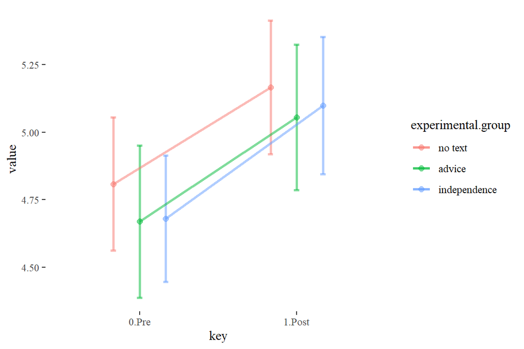

```r
df.def.error  %>%
  select(experimental.group,
         credibility.EMA,
         credibility.post) %>%  drop_na() %>%
  gather("key","value",-experimental.group) %>%
  mutate(key = Recode(key,"'credibility.EMA'='0.Pre';'credibility.post'='1.Post'")) %>%

ggplot(aes(x=key,y=value,color=experimental.group))+
      stat_summary(fun.data = mean_cl_normal, geom = "errorbar", alpha=0.5,width=0.1,size=1,position=position_dodge(0.5)) +
  stat_summary(fun = mean, geom = "point", alpha=0.5,size=2,position=position_dodge(0.5))+
  stat_summary(fun = mean, geom = "line", alpha=0.5,size=1,position=position_dodge(0.5), aes(group = experimental.group))+
  theme_tufte()
```

## 5.3 Regression

```r
t1 <- df.def.error %>% mutate(id = row_number()) %>%
  select(experimental.group,
         id,
         credibility.EMA,
         credibility.post) %>%
  drop_na() %>%
  gather("key","value",-experimental.group,-id) %>%
  mutate(post = key %>% Recode("'credibility.EMA'= 0;'credibility.post'=1"),
         EMA.credibility = value)


tmod1 <- lmer(EMA.credibility ~ post + +(1|id),
                       data = t1)

tmod2 <- tmod1 %>% update(.~.+experimental.group)


tmod3 <- tmod2 %>% update(.~. + post*experimental.group)

tab_model(tmod2,tmod3,
          show.ci = F,
          show.se = T,
          collapse.se = T,
          emph.p = F)
```

|  | EMA credibility |  | EMA credibility |  |
| --- | --- | --- | --- | --- |
| Predictors | Estimates | p | Estimates | p |
| (Intercept) | 4.79 (0.12) | <0.001 | 4.81 (0.13) | <0.001 |
| post | 0.39 (0.06) | <0.001 | 0.36 (0.11) | 0.001 |
| experimental.group [advice] | -0.13 (0.17) | 0.454 | -0.14 (0.18) | 0.447 |
| experimental.group [independence] | -0.10 (0.17) | 0.562 | -0.13 (0.18) | 0.488 |
| post * experimental.group [advice] |  |  | 0.03 (0.15) | 0.852 |
| post * experimental.group [independence] |  |  | 0.06 (0.15) | 0.688 |
| Random Effects |  |  |  |  |
| σ<sup>2</sup> | 0.67 |  | 0.67 |  |
| τ<sub>00</sub> | 1.40 <sub>id</sub> |  | 1.40 <sub>id</sub> |  |
| ICC | 0.68 |  | 0.68 |  |
| N | 369 <sub>id</sub> |  | 369 <sub>id</sub> |  |
| Observations | 738 |  | 738 |  |
| Marginal R<sup>2</sup> / Conditional R<sup>2</sup> | 0.019 / 0.684 |  | 0.019 / 0.682 |  |

# 6 Time

## 6.1 Survey duration

### 6.1.1 Histogram

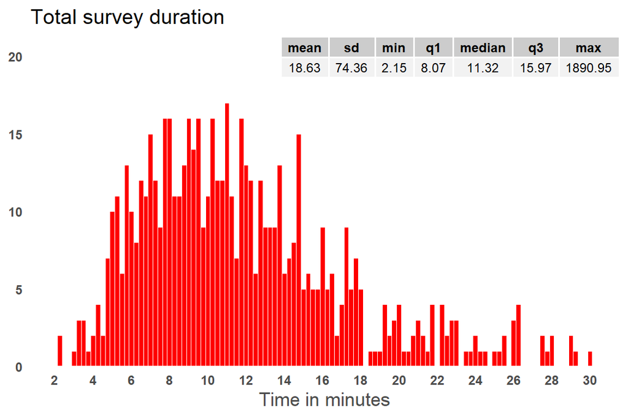

```r
df.def.error %>% filter(duration < 30) %>%
plot_frq((duration),
        geom.colors = ggplot2::alpha("red",0.8),
        type = "hist",
        geom.size = 0.25) +
  theme(axis.text = element_text(face = "bold",  size= 9)) + labs(title = "Total survey duration") +  scale_x_continuous(name="Time in minutes", breaks = seq(0,30, 2)) + scale_y_continuous(expand = expansion(c(0, 0.25))) + annotate(geom = "table", x = Inf, y = Inf, label = list(table.duration))
```

## 6.2 Do participants read the information about the case?

### 6.2.1 Page submission - introduction of case

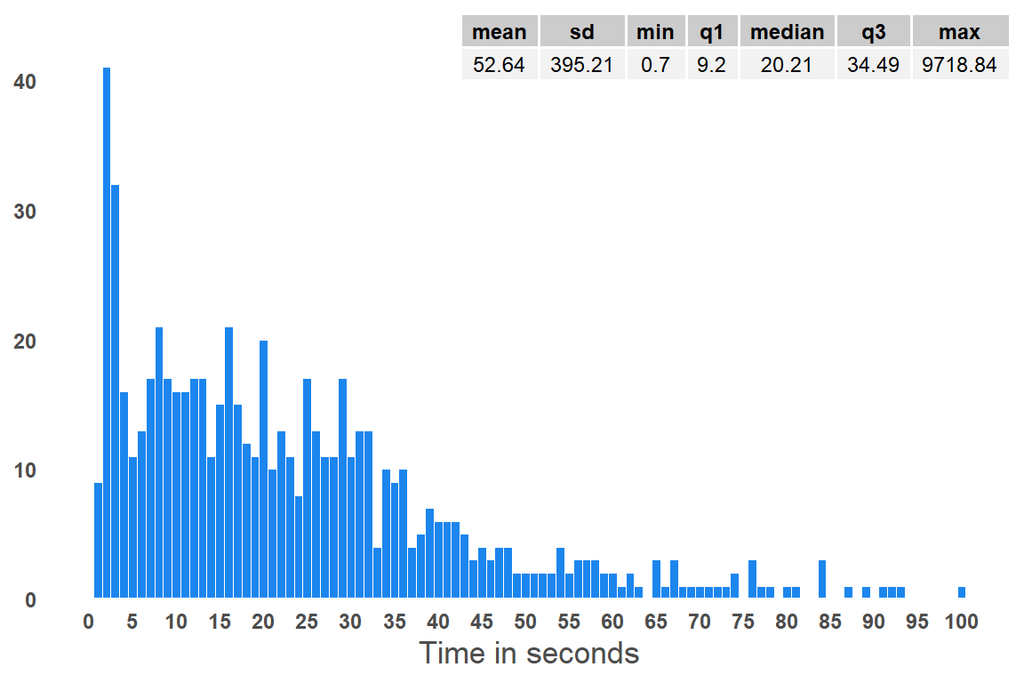

```r
df.def.error %>% filter(intro.submit < 100) %>%
plot_frq((intro.submit),
        geom.colors = ggplot2::alpha("dodgerblue2",0.8),
        type = "hist",
        geom.size = 1) +
  theme(axis.text = element_text(face = "bold",  size= 9)) +
  scale_x_continuous(name="Time in seconds",breaks = seq(0,100,5)) + scale_y_continuous(expand = expansion(c(0, 0.1))) + annotate(geom = "table", x = Inf, y = Inf, label = list(table.intro.submit))
```

### 6.2.2 Page submission - manipulation

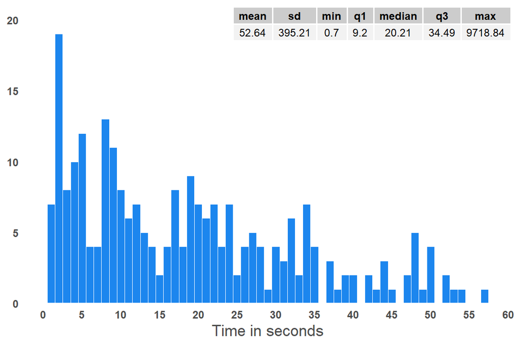

```r
df.def.error %>% filter(manipulation.submit > 0 & manipulation.submit < 60) %>%
plot_frq((manipulation.submit),
        geom.colors = ggplot2::alpha("dodgerblue2",0.8),
        type = "hist",
        geom.size = 1) +
  theme(axis.text = element_text(face = "bold",  size= 9)) +
  scale_x_continuous(name="Time in seconds",breaks = seq(0,100,5)) + scale_y_continuous(expand = expansion(c(0, 0.1))) + annotate(geom = "table", x = Inf, y = Inf, label = list(table.intro.submit))
```

### 6.2.3 Page submission - EMA’s decision

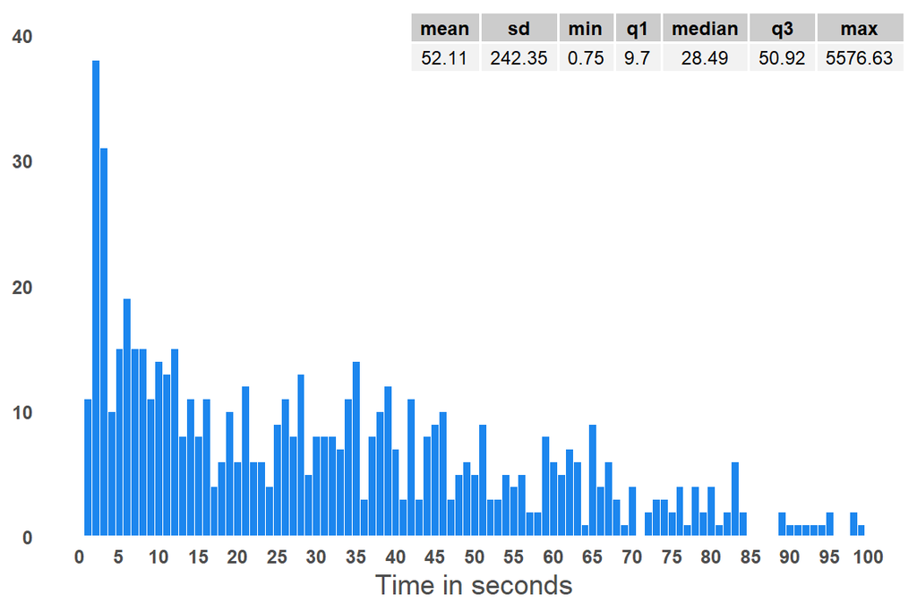

```r
df.def.error %>% filter(decision.submit < 100) %>%
plot_frq((decision.submit),
        geom.colors = ggplot2::alpha("dodgerblue2",0.8),
        type = "hist",
        geom.size = 1) +
  theme(axis.text = element_text(face = "bold",  size= 9)) +
  scale_x_continuous(name= "Time in seconds", breaks = seq(0,100,5)) + scale_y_continuous(expand = expansion(c(0, 0.1))) + annotate(geom = "table", x = Inf, y = Inf, label = list(table.decision.submit))
```

## 6.3 Time and …

### 6.3.1 …experimental groups

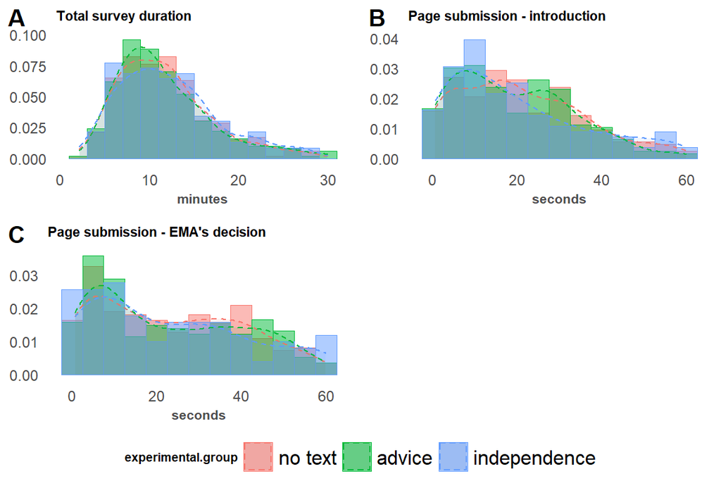

```r
p5 <- df.def.error %>% filter(duration < 30) %>% ggplot(aes(x= duration, color = experimental.group, fill = experimental.group)) + geom_histogram(aes(y=..density..), alpha=0.5, position="identity", binwidth = 2) +
 geom_density(alpha= .1, linetype= "dashed") + labs(title = "Total survey duration", x = "minutes") + theme(axis.title.y = element_blank(), title = element_text(size = 7, face = "bold"),  axis.text = element_text(size = 9))

p6  <- df.def.error %>% filter(intro.submit < 60) %>% ggplot(aes(x= intro.submit, color = experimental.group, fill = experimental.group)) + geom_histogram(aes(y=..density..), alpha=0.5, position="identity", binwidth = 5) +
 geom_density(alpha= .1, linetype= "dashed") + labs(title = "Page submission - introduction", x = "seconds") + theme(axis.title.y = element_blank(), title = element_text(size = 7, face = "bold"),  axis.text = element_text(size = 9))


p8 <- df.def.error %>% filter(decision.submit < 60) %>% ggplot(aes(x=decision.submit, color = experimental.group, fill = experimental.group)) +
 geom_histogram(aes(y=..density..), alpha=0.5, position="identity", binwidth = 5) +
 geom_density(alpha= .1, linetype= "dashed") + labs(title = "Page submission - EMA's decision", x = "seconds") + theme(axis.title.y = element_blank(), title = element_text(size = 7, face = "bold"),  axis.text = element_text(size = 9))

ggarrange(p5, p6, p8, nrow = 2, ncol = 2, labels="AUTO", legend = "bottom", common.legend = TRUE)
```